# Real-World Data Wrangling

## 1. Gather data

In this section, we will extract data using at least two different data gathering methods and combine the data.

### **1.1.** Problem Statement

How does the streaming revolution compare to traditional theatrical releases in terms of financial performance, audience reception, and content characteristics, and how have these metrics evolved over time when accounting for inflation?

The film industry has undergone a dramatic shift from theatrical dominance to streaming platforms, but how do these distribution channels compare in terms of content characteristics, audience engagement, and financial viability?

This project merges TMDb theatrical movie data, IMDb ratings, four major streaming platform catalogs, and Federal Reserve CPI data to conduct a comprehensive analysis of streaming-exclusive versus theatrical releases. By adjusting all budgets and revenues to 2024 dollars using inflation data, I can fairly compare financial performance across six decades (1960-2024) and determine whether the "streaming revolution" represents truly different content or simply a new distribution channel for similar movies.

The primary data wrangling challenge involves fuzzy matching movies across datasets with inconsistent identifiers, requiring normalized title matching and year-based validation.

### **1.2.** Dataset Overview

This project combines four distinct data sources gathered using three different methods:

[output not shown]

The combination of these datasets enables analysis of streaming versus theatrical releases while ensuring fair financial comparisons across six decades.

```python
# Import statements for packages used in analysis
import httpx
import os
import re
import zlib

import matplotlib.pyplot as plt
import numpy as np
import pandas as pd
import seaborn as sb

from collections import Counter
from dotenv import load_dotenv
from pandas.api.types import is_numeric_dtype
from scipy import stats
from unidecode import unidecode
from urllib.parse import urlparse

## It's OK if this file doesn't exist as the API results are
## saved to a file in the project and the API code will check
## for the file before using the API key this would retrieve.
load_dotenv(dotenv_path=f"{os.path.expanduser('~/.env')}")

# Magic word for inline visualizations
%matplotlib inline

# Set default figure size for better readability
sb.set_style('whitegrid')
plt.rcParams['figure.figsize'] = (12, 6)

RAW_DATA_PATH = 'data/raw'
CLEAN_DATA_PATH='data/clean'
```

```python
## Data gathering and display functions
def download_and_save_file(url, local_filename, path=RAW_DATA_PATH, download_if_exists=False):
    """
    Downloads a file from a URL and saves it locally.
    By default the file is saved to 'RAW_DATA_PATH' path.

    If the file is gzipped, it's decompressed on-the-fly and
    written as uncompressed data.

    Args:
        url (str): URL of file to download.
        local_filename (str): Name of file to save locally.
    """
    filepath = f"{path}/{local_filename}"

    if os.path.exists(filepath) and download_if_exists is False:
        print(f"{filepath} already exists. If you wish to re-download it, set download_if_exists=True")
        return

    try:
        with httpx.stream("GET", url, headers={"Accept-Encoding": "gzip"}) as response:
            # Raise an exception for bad status codes
            response.raise_for_status()

            headers = response.headers
            is_gzip = False

            print(f"Downloading {url} --> {filepath}")

            # Check if response is gzipped
            if 'content-encoding' in headers and 'gzip' in headers['content-encoding']:
                    is_gzip = True

            elif 'content-type' in headers and 'binary/octet-stream' in headers['content-type']:
                # AWS likes to send this back; just check the extension
                _, extension = os.path.splitext(urlparse(url).path)

                if extension == '.gz':
                    is_gzip = True

            # Decompress file if it's gzipped
            if is_gzip is True:
                print("Decompressing gzip content...")

                decompressor = zlib.decompressobj(wbits=zlib.MAX_WBITS | 16)
                download_size = 0
                count = 0

                with open(filepath, "wb") as outfile:
                    for chunk in response.iter_bytes():
                        count += 1
                        download_size += len(chunk)
                        decompressed_chunk = decompressor.decompress(chunk)

                        if download_size % 1000000 == 0:
                            print(f"Downloaded bytes: {download_size:,}")

                        outfile.write(decompressed_chunk)

                print(f"Downloaded {count:,} chunks for file size {download_size:,}")

                remaining_data = decompressor.flush()
                if remaining_data:
                    with open(filepath, "wb") as outfile:
                        outfile.write(remaining_data)


            # If not gzipped, just write raw content to the output file
            else:
                with open(filepath, 'wb') as outfile:
                    for chunk in response.iter_bytes():
                        outfile.write(chunk)

            # Give the user feedback
            print(f"File '{local_filename}' downloaded successfully from '{url}'")

    # Check for various issues
    except httpx.HTTPStatusError as e:
        print(f"HTTP error occurred: {e}")

    except httpx.RequestError as e:
        print(f"An error occurred while requesting {url}: {e}")

    except IOError as e:
        print(f"Error saving file '{local_filename}': {e}")

def display_shape(df):
    """
    Output rows and columns of dataframe
    """
    print(f"\nRows: {df.shape[0]:,}")
    print(f"Columns: {df.shape[1]:,}\n")
```

#### TMDb Movies Dataset

The TMDb (The Movie Database) dataset provides comprehensive information about 10,000 theatrical movies, representing the foundation of this analysis. This dataset is particularly valuable because it includes both original and inflation-adjusted financial figures (budget_adj and revenue_adj to 2010 dollars), extensive production metadata, and audience reception metrics. TMDb's community-driven model ensures broad coverage of theatrical releases while maintaining high data quality through active curation.

Source URL: https://www.kaggle.com/datasets/juzershakir/tmdb-movies-dataset

Type: CSV (6.85 MB)

Method: Manual download from Kaggle

**Dataset variables:**

- id (int) - TMDb unique identifier
- imdb_id (string) - IMDb identifier for cross-dataset linking
- popularity (float) - TMDb popularity score
- budget (int) - Production budget in nominal dollars
- revenue (int) - Total box office revenue in nominal dollars
- original_title (string) - Original title
- cast (string) - Cast members (pipe-delimited)
- homepage (string) - Official movie homepage URL
- director (string) - Director name
- tagline (string) - Marketing catchphrase
- keywords (string) - Descriptive keywords (pipe-delimited)
- overview (string) - Plot synopsis
- runtime (int) - Duration in minutes
- genres (string) - Movie genres (pipe-delimited)
- production_companies (string) - Production companies (pipe-delimited)
- release_date (string) - Release date (format: 6/9/2015)
- vote_count (int) - Total number of TMDb user votes
- vote_average (float) - Average TMDb user rating (0-10 scale)
- release_year (int) - Release year
- budget_adj (float) - Budget adjusted to 2010 dollars
- revenue_adj (float) - Revenue adjusted to 2010 dollars

**Why this dataset:** TMDb serves as the core theatrical release dataset because it combines financial data (budget/revenue), audience reception (ratings/votes), production details (cast/director/companies), and content characteristics (genres/runtime) in a single source. The pre-existing inflation adjustment to 2010 demonstrates awareness of temporal comparison challenges, though this project will re-adjust all figures to 2024 dollars for consistency. The imdb_id field enables precise linking to IMDb data, while the comprehensive metadata supports fuzzy matching to streaming platforms where IDs are absent.

**Significance of variables:**

- **id/imdb_id:** Primary keys for merging with IMDb and tracking across datasets
- **budget/revenue (and _adj versions):** Core financial metrics for profitability analysis; will be re-adjusted to 2024 dollars
- **vote_average/vote_count:** TMDb's rating system for comparison with IMDb's averageRating/numVotes
- **genres/runtime:** Content characteristics for analyzing streaming vs theatrical patterns
- **cast/director:** Enable talent crossover analysis between distribution channels
- **release_year/release_date:** Temporal analysis and fuzzy matching keys
- **popularity:** TMDb-specific engagement metric not available in other datasets

```python
# Load dataset
tmdb_movies_raw_df = pd.read_csv(f'{RAW_DATA_PATH}/tmdb_movies_data.csv')

display_shape(tmdb_movies_raw_df)
display(tmdb_movies_raw_df.head())
```

```
Rows: 10,866
Columns: 21
```

|  | id | imdb_id | popularity | budget | revenue | original_title | cast | homepage | director | tagline | ... | overview | runtime | genres | production_companies | release_date | vote_count | vote_average | release_year | budget_adj | revenue_adj |
| --- | --- | --- | --- | --- | --- | --- | --- | --- | --- | --- | --- | --- | --- | --- | --- | --- | --- | --- | --- | --- | --- |
| 0 | 135397 | tt0369610 | 32.985763 | 150000000 | 1513528810 | Jurassic World | Chris Pratt\|Bryce Dallas Howard\|Irrfan Khan\|Vi... | http://www.jurassicworld.com/ | Colin Trevorrow | The park is open. | ... | Twenty-two years after the events of Jurassic ... | 124 | Action\|Adventure\|Science Fiction\|Thriller | Universal Studios\|Amblin Entertainment\|Legenda... | 6/9/15 | 5562 | 6.5 | 2015 | 1.379999e+08 | 1.392446e+09 |
| 1 | 76341 | tt1392190 | 28.419936 | 150000000 | 378436354 | Mad Max: Fury Road | Tom Hardy\|Charlize Theron\|Hugh Keays-Byrne\|Nic... | http://www.madmaxmovie.com/ | George Miller | What a Lovely Day. | ... | An apocalyptic story set in the furthest reach... | 120 | Action\|Adventure\|Science Fiction\|Thriller | Village Roadshow Pictures\|Kennedy Miller Produ... | 5/13/15 | 6185 | 7.1 | 2015 | 1.379999e+08 | 3.481613e+08 |
| 2 | 262500 | tt2908446 | 13.112507 | 110000000 | 295238201 | Insurgent | Shailene Woodley\|Theo James\|Kate Winslet\|Ansel... | http://www.thedivergentseries.movie/#insurgent | Robert Schwentke | One Choice Can Destroy You | ... | Beatrice Prior must confront her inner demons ... | 119 | Adventure\|Science Fiction\|Thriller | Summit Entertainment\|Mandeville Films\|Red Wago... | 3/18/15 | 2480 | 6.3 | 2015 | 1.012000e+08 | 2.716190e+08 |
| 3 | 140607 | tt2488496 | 11.173104 | 200000000 | 2068178225 | Star Wars: The Force Awakens | Harrison Ford\|Mark Hamill\|Carrie Fisher\|Adam D... | http://www.starwars.com/films/star-wars-episod... | J.J. Abrams | Every generation has a story. | ... | Thirty years after defeating the Galactic Empi... | 136 | Action\|Adventure\|Science Fiction\|Fantasy | Lucasfilm\|Truenorth Productions\|Bad Robot | 12/15/15 | 5292 | 7.5 | 2015 | 1.839999e+08 | 1.902723e+09 |
| 4 | 168259 | tt2820852 | 9.335014 | 190000000 | 1506249360 | Furious 7 | Vin Diesel\|Paul Walker\|Jason Statham\|Michelle ... | http://www.furious7.com/ | James Wan | Vengeance Hits Home | ... | Deckard Shaw seeks revenge against Dominic Tor... | 137 | Action\|Crime\|Thriller | Universal Pictures\|Original Film\|Media Rights ... | 4/1/15 | 2947 | 7.3 | 2015 | 1.747999e+08 | 1.385749e+09 |

5 rows × 21 columns

#### IMDb Non-Commercial Datasets

IMDb provides free access to subsets of their data for non-commercial use, refreshed daily. This dataset extends the TMDb data with additional ratings and metadata, and provides validation for fuzzy matching when IMDb IDs are missing. IMDb's community-driven ratings represent a different audience demographic than TMDb, enabling comparison of rating systems.

Source URL: https://datasets.imdbws.com/

Type: TSV (Tab-Separated Values), gzip-compressed

Method: Programmatic download using Python httpx library

**Files Used:**

**title.basics.tsv.gz** - Core movie metadata

- tconst (string) - IMDb unique identifier (e.g., tt0111161)
- titleType (string) - Format type (movie, short, tvSeries, etc.)
- primaryTitle (string) - Popular title used in marketing
- originalTitle (string) - Original language title
- isAdult (boolean) - Adult content flag (0 or 1)
- startYear (YYYY) - Release year
- runtimeMinutes (int) - Duration in minutes
- genres (string array) - Up to three genres (comma-separated)

**title.ratings.tsv.gz** - Community ratings

- tconst (string) - IMDb unique identifier
- averageRating (float) - Weighted average rating (1-10 scale)
- numVotes (int) - Total number of votes

**Why this dataset:** IMDb's rating system is well-established and trusted, providing an alternative measure of audience reception. The tconst identifier enables precise linking to TMDb via imdb_id field, while the comprehensive coverage helps identify theatrical releases that may be missing from TMDb. The daily-updated nature ensures current data.

**Significance of variables:**

- **tconst/averageRating/numVotes:** Enable comparison of IMDb vs TMDb rating systems and vote engagement
- **titleType:** Filters dataset to movies only (excluding TV series, shorts)
- **startYear/runtimeMinutes:** Provide additional data points for movies missing this info in TMDb
- **genres:** Cross-validation of genre classifications across systems

```python
# Get files via URL download
URL = "https://datasets.imdbws.com/title.basics.tsv.gz"
LOCAL_FILE = "imdb_title_basics.tsv"

download_and_save_file(URL, LOCAL_FILE)

# Load dataset - note that this dataset is quite large at almost 1GB on disk
imdb_title_basics_raw_df = pd.read_csv(f'{RAW_DATA_PATH}/{LOCAL_FILE}', sep='\t')

display_shape(imdb_title_basics_raw_df)
display(imdb_title_basics_raw_df.head())
```

```
data/raw/imdb_title_basics.tsv already exists. If you wish to re-download it, set download_if_exists=True

Rows: 12,116,115
Columns: 9
```

|  | tconst | titleType | primaryTitle | originalTitle | isAdult | startYear | endYear | runtimeMinutes | genres |
| --- | --- | --- | --- | --- | --- | --- | --- | --- | --- |
| 0 | tt0000001 | short | Carmencita | Carmencita | 0 | 1894 | \N | 1 | Documentary,Short |
| 1 | tt0000002 | short | Le clown et ses chiens | Le clown et ses chiens | 0 | 1892 | \N | 5 | Animation,Short |
| 2 | tt0000003 | short | Poor Pierrot | Pauvre Pierrot | 0 | 1892 | \N | 5 | Animation,Comedy,Romance |
| 3 | tt0000004 | short | Un bon bock | Un bon bock | 0 | 1892 | \N | 12 | Animation,Short |
| 4 | tt0000005 | short | Blacksmith Scene | Blacksmith Scene | 0 | 1893 | \N | 1 | Short |

```python
# Get files via URL download
URL = "https://datasets.imdbws.com/title.ratings.tsv.gz"
LOCAL_FILE="imdb_title_ratings.tsv"

download_and_save_file(URL, LOCAL_FILE)

# Load dataset
imdb_title_ratings_raw_df = pd.read_csv(f'{RAW_DATA_PATH}/{LOCAL_FILE}', sep='\t')

display_shape(imdb_title_ratings_raw_df)
display(imdb_title_ratings_raw_df.head())
```

```
data/raw/imdb_title_ratings.tsv already exists. If you wish to re-download it, set download_if_exists=True

Rows: 1,607,373
Columns: 3
```

|  | tconst | averageRating | numVotes |
| --- | --- | --- | --- |
| 0 | tt0000001 | 5.7 | 2187 |
| 1 | tt0000002 | 5.5 | 307 |
| 2 | tt0000003 | 6.4 | 2273 |
| 3 | tt0000004 | 5.2 | 196 |
| 4 | tt0000005 | 6.2 | 3012 |

#### Streaming Platform Catalogs

Four major streaming platform datasets provide comprehensive coverage of content available on Netflix, Hulu, Disney+, and Amazon Prime as of mid-2021. These datasets enable identification of streaming-exclusive content (never released theatrically) versus theatrical films later added to streaming platforms. The consistent schema across platforms facilitates comparison of content strategies.

**Datasets:**

- Netflix: https://www.kaggle.com/datasets/shivamb/netflix-shows (~8K titles)
- Hulu: https://www.kaggle.com/datasets/shivamb/hulu-movies-and-tv-shows (~3K titles)
- Disney+: https://www.kaggle.com/datasets/shivamb/disney-movies-and-tv-shows (~1.3K titles)
- Amazon Prime: https://www.kaggle.com/datasets/shivamb/amazon-prime-movies-and-tv-shows (~10K titles)

Type: CSV

Method: Manual download from Kaggle (all four datasets)

**Shared Schema:**

- show_id (string) - Unique identifier per platform
- type (string) - "Movie" or "TV Show"
- title (string) - Content title
- director (string) - Director name(s)
- cast (string) - Cast members (comma-separated)
- country (string) - Production country
- date_added (string) - Date added to platform (e.g., "September 25, 2021")
- release_year (int) - Original release year
- rating (string) - Content rating (PG-13, TV-MA, etc.)
- duration (string) - Runtime (e.g., "90 min" or "2 Seasons")
- listed_in (string) - Genres (comma-separated)
- description (string) - Synopsis

**Why these datasets:** Streaming platforms represent the industry's future, but comprehensive availability data isn't accessible via APIs without commercial partnerships. These Kaggle datasets provide a snapshot of four major platforms' catalogs at a single point in time (2021), enabling analysis of platform content strategies. The lack of consistent identifiers (no TMDb/IMDb IDs) creates an authentic data wrangling challenge requiring fuzzy matching.

**Significance of variables:**

- **type:** Filters to movies only (excluding TV shows)
- **title/release_year:** Primary keys for fuzzy matching to theatrical databases
- **director/cast:** Enable cross-validation of matches and analysis of talent migration to streaming
- **date_added:** Indicates when content became available (may differ from release_year)
- **listed_in:** Genre analysis comparing streaming vs theatrical content preferences
- **duration:** Identifies potential data quality issues (TV shows mis-labeled as movies)

> **Amazon Prime**

```python
# I decided to manually load these datasets into the project.
# Working with the kaggle and kagglehub Python packages is more trouble than it's worth.

amazon_prime_titles_raw_df = pd.read_csv(f'{RAW_DATA_PATH}/amazon_prime_titles.csv')
display_shape(amazon_prime_titles_raw_df)
display(amazon_prime_titles_raw_df.head())
```

```
Rows: 9,668
Columns: 12
```

|  | show_id | type | title | director | cast | country | date_added | release_year | rating | duration | listed_in | description |
| --- | --- | --- | --- | --- | --- | --- | --- | --- | --- | --- | --- | --- |
| 0 | s1 | Movie | The Grand Seduction | Don McKellar | Brendan Gleeson, Taylor Kitsch, Gordon Pinsent | Canada | March 30, 2021 | 2014 | NaN | 113 min | Comedy, Drama | A small fishing village must procure a local d... |
| 1 | s2 | Movie | Take Care Good Night | Girish Joshi | Mahesh Manjrekar, Abhay Mahajan, Sachin Khedekar | India | March 30, 2021 | 2018 | 13+ | 110 min | Drama, International | A Metro Family decides to fight a Cyber Crimin... |
| 2 | s3 | Movie | Secrets of Deception | Josh Webber | Tom Sizemore, Lorenzo Lamas, Robert LaSardo, R... | United States | March 30, 2021 | 2017 | NaN | 74 min | Action, Drama, Suspense | After a man discovers his wife is cheating on ... |
| 3 | s4 | Movie | Pink: Staying True | Sonia Anderson | Interviews with: Pink, Adele, Beyoncé, Britney... | United States | March 30, 2021 | 2014 | NaN | 69 min | Documentary | Pink breaks the mold once again, bringing her ... |
| 4 | s5 | Movie | Monster Maker | Giles Foster | Harry Dean Stanton, Kieran O'Brien, George Cos... | United Kingdom | March 30, 2021 | 1989 | NaN | 45 min | Drama, Fantasy | Teenage Matt Banting wants to work with a famo... |

> **Disney Plus**

```python
disney_plus_titles_raw_df = pd.read_csv(f'{RAW_DATA_PATH}/disney_plus_titles.csv')
display_shape(disney_plus_titles_raw_df)
display(disney_plus_titles_raw_df.head())
```

```
Rows: 1,450
Columns: 12
```

|  | show_id | type | title | director | cast | country | date_added | release_year | rating | duration | listed_in | description |
| --- | --- | --- | --- | --- | --- | --- | --- | --- | --- | --- | --- | --- |
| 0 | s1 | Movie | Duck the Halls: A Mickey Mouse Christmas Special | Alonso Ramirez Ramos, Dave Wasson | Chris Diamantopoulos, Tony Anselmo, Tress MacN... | NaN | November 26, 2021 | 2016 | TV-G | 23 min | Animation, Family | Join Mickey and the gang as they duck the halls! |
| 1 | s2 | Movie | Ernest Saves Christmas | John Cherry | Jim Varney, Noelle Parker, Douglas Seale | NaN | November 26, 2021 | 1988 | PG | 91 min | Comedy | Santa Claus passes his magic bag to a new St. ... |
| 2 | s3 | Movie | Ice Age: A Mammoth Christmas | Karen Disher | Raymond Albert Romano, John Leguizamo, Denis L... | United States | November 26, 2021 | 2011 | TV-G | 23 min | Animation, Comedy, Family | Sid the Sloth is on Santa's naughty list. |
| 3 | s4 | Movie | The Queen Family Singalong | Hamish Hamilton | Darren Criss, Adam Lambert, Derek Hough, Alexa... | NaN | November 26, 2021 | 2021 | TV-PG | 41 min | Musical | This is real life, not just fantasy! |
| 4 | s5 | TV Show | The Beatles: Get Back | NaN | John Lennon, Paul McCartney, George Harrison, ... | NaN | November 25, 2021 | 2021 | NaN | 1 Season | Docuseries, Historical, Music | A three-part documentary from Peter Jackson ca... |

> **Hulu**

```python
hulu_titles_raw_df = pd.read_csv(f'{RAW_DATA_PATH}/hulu_titles.csv')
display_shape(hulu_titles_raw_df)
display(hulu_titles_raw_df.head())
```

```
Rows: 3,073
Columns: 12
```

|  | show_id | type | title | director | cast | country | date_added | release_year | rating | duration | listed_in | description |
| --- | --- | --- | --- | --- | --- | --- | --- | --- | --- | --- | --- | --- |
| 0 | s1 | Movie | Ricky Velez: Here's Everything | NaN | NaN | NaN | October 24, 2021 | 2021 | TV-MA | NaN | Comedy, Stand Up | Comedian Ricky Velez bares it all with his ho... |
| 1 | s2 | Movie | Silent Night | NaN | NaN | NaN | October 23, 2021 | 2020 | NaN | 94 min | Crime, Drama, Thriller | Mark, a low end South London hitman recently r... |
| 2 | s3 | Movie | The Marksman | NaN | NaN | NaN | October 23, 2021 | 2021 | PG-13 | 108 min | Action, Thriller | A hardened Arizona rancher tries to protect an... |
| 3 | s4 | Movie | Gaia | NaN | NaN | NaN | October 22, 2021 | 2021 | R | 97 min | Horror | A forest ranger and two survivalists with a cu... |
| 4 | s5 | Movie | Settlers | NaN | NaN | NaN | October 22, 2021 | 2021 | NaN | 104 min | Science Fiction, Thriller | Mankind's earliest settlers on the Martian fro... |

> **Netflix**

```python
netflix_titles_raw_df = pd.read_csv(f'{RAW_DATA_PATH}/netflix_titles.csv')
display_shape(netflix_titles_raw_df)
display(netflix_titles_raw_df.head())
```

```
Rows: 8,807
Columns: 12
```

|  | show_id | type | title | director | cast | country | date_added | release_year | rating | duration | listed_in | description |
| --- | --- | --- | --- | --- | --- | --- | --- | --- | --- | --- | --- | --- |
| 0 | s1 | Movie | Dick Johnson Is Dead | Kirsten Johnson | NaN | United States | September 25, 2021 | 2020 | PG-13 | 90 min | Documentaries | As her father nears the end of his life, filmm... |
| 1 | s2 | TV Show | Blood & Water | NaN | Ama Qamata, Khosi Ngema, Gail Mabalane, Thaban... | South Africa | September 24, 2021 | 2021 | TV-MA | 2 Seasons | International TV Shows, TV Dramas, TV Mysteries | After crossing paths at a party, a Cape Town t... |
| 2 | s3 | TV Show | Ganglands | Julien Leclercq | Sami Bouajila, Tracy Gotoas, Samuel Jouy, Nabi... | NaN | September 24, 2021 | 2021 | TV-MA | 1 Season | Crime TV Shows, International TV Shows, TV Act... | To protect his family from a powerful drug lor... |
| 3 | s4 | TV Show | Jailbirds New Orleans | NaN | NaN | NaN | September 24, 2021 | 2021 | TV-MA | 1 Season | Docuseries, Reality TV | Feuds, flirtations and toilet talk go down amo... |
| 4 | s5 | TV Show | Kota Factory | NaN | Mayur More, Jitendra Kumar, Ranjan Raj, Alam K... | India | September 24, 2021 | 2021 | TV-MA | 2 Seasons | International TV Shows, Romantic TV Shows, TV ... | In a city of coaching centers known to train I... |

#### Consumer Price Index (CPI) for Inflation Adjustment

The Federal Reserve Economic Data (FRED) provides historical Consumer Price Index data necessary for adjusting movie budgets and revenues to constant 2024 dollars. Without inflation adjustment, comparing a 1970s film budget to a 2020s budget is meaningless. The CPI-U (Consumer Price Index for All Urban Consumers) is the standard measure used by economists for this purpose.

Source URL: https://fred.stlouisfed.org/series/CPIAUCSL

Type: JSON (API response)

Method: API access via FRED API (programmatic)

**Dataset variables:**

- date (string) - Observation date (YYYY-MM-DD format)
- value (float) - CPI index value (1982-84 = 100 baseline)
- year (int) - Year extracted from date
- cpi (float) - Annual average CPI value

**Why this dataset:** Inflation has been substantial over the 65-year span of this analysis (1960-2024). A \$1 million budget in 1960 equals approximately \$10.4 million in 2024 dollars. Without adjustment, financial analysis would be dominated by recency bias, making modern films appear far more expensive than historical films when they may actually be comparable in real terms. The FRED API provides authoritative, regularly-updated data from the U.S. Bureau of Labor Statistics.

**Significance of variables:**

- **year/cpi:** Used to calculate inflation multiplier: `adjusted_amount = original * (CPI_2024 / CPI_year)`
- **Annual averaging:** Smooths monthly volatility for more stable year-over-year comparisons

**Adjustment formula:**

```
budget_adj_2024 = budget_original × (CPI_2024 / CPI_release_year)
revenue_adj_2024 = revenue_original × (CPI_2024 / CPI_release_year)
```

```python
def get_cpi_data(start_year=1960, end_year=2025, local_filename='cpi_data.json', path=RAW_DATA_PATH, download_if_exists=False):
    """
    Get CPI data from FRED API
    CPI-U (Consumer Price Index for all Urban consumers)
    """

    filepath = f"{path}/{local_filename}"

    # Get cached data if we have it
    if os.path.exists(filepath) and download_if_exists is False:
        print(f"{filepath} already exists. If you wish to re-download it, set download_if_exists=True")
        return pd.read_json(filepath)

    url = 'https://api.stlouisfed.org/fred/series/observations'
    params = {
        'series_id': 'CPIAUCSL',
        'api_key': os.getenv('FRED_API'),
        'file_type': 'json',
        'observation_start': f'{start_year}-01-01',
        'observation_end': f'{end_year}-12-31',
        'frequency': 'a'
    }

    try:
        # Get the data as JSON
        response = httpx.get(url, params=params)
        response.raise_for_status()

        data = response.json()

        # Create dataframe
        cpi_df = pd.DataFrame(data['observations'])

        # Remove invalid data rows
        cpi_df = cpi_df[cpi_df['value'] != "."]

        # Transform data
        cpi_df['year'] = pd.to_datetime(cpi_df['date']).dt.year
        cpi_df['cpi'] = pd.to_numeric(cpi_df['value'])

        cpi_df = cpi_df[['year', 'cpi']]

        # Cache transformed data to disk
        cpi_df.to_json(filepath, orient='records')

        return cpi_df

    except httpx.HTTPStatusError as e:
        print(f"Error during request: {e}")

    except httpx.RequestError as e:
        print(f"An error occurred while requesting: {e}")
```

```python
cpi_df = get_cpi_data()
display_shape(cpi_df)
display(cpi_df.head())
display(cpi_df['year'].unique())
```

```
data/raw/cpi_data.json already exists. If you wish to re-download it, set download_if_exists=True

Rows: 65
Columns: 2
```

|  | year | cpi |
| --- | --- | --- |
| 0 | 1960 | 29.585 |
| 1 | 1961 | 29.902 |
| 2 | 1962 | 30.253 |
| 3 | 1963 | 30.633 |
| 4 | 1964 | 31.038 |

```
array([1960, 1961, 1962, 1963, 1964, 1965, 1966, 1967, 1968, 1969, 1970,
       1971, 1972, 1973, 1974, 1975, 1976, 1977, 1978, 1979, 1980, 1981,
       1982, 1983, 1984, 1985, 1986, 1987, 1988, 1989, 1990, 1991, 1992,
       1993, 1994, 1995, 1996, 1997, 1998, 1999, 2000, 2001, 2002, 2003,
       2004, 2005, 2006, 2007, 2008, 2009, 2010, 2011, 2012, 2013, 2014,
       2015, 2016, 2017, 2018, 2019, 2020, 2021, 2022, 2023, 2024])
```

## **2. Assess Data**

Before cleaning and merging the datasets, we must identify data quality and tidiness issues that could impact our analysis. This assessment phase follows a structured approach: each issue is evaluated both visually (inspecting sample data) and programmatically (using pandas methods to quantify the problem), with clear justifications for why each issue matters for our research questions.

This section documents the four most critical issues—two quality problems and two tidiness violations—that must be resolved before proceeding with the streaming vs theatrical analysis. Quality issues relate to the accuracy, completeness, and validity of individual data values (missing identifiers, incorrect null encodings, zero-value anomalies). Tidiness issues concern the structural organization of data (observational units split across tables, multiple values stored in single columns).

While these four issues represent the most significant barriers to analysis, additional data quality concerns will be identified and addressed during the cleaning phase. These include filtering datasets to relevant records (movies only, excluding TV shows), standardizing column names and data types, handling delimiter inconsistencies across platforms, and selecting the subset of variables needed for our specific research questions. The comprehensive cleaning strategy will be detailed in Section 3.

**Assessment approach:**

- **Visual assessment:** Display sample data using `.head()`, `.sample()`, or filtered subsets to observe patterns
- **Programmatic assessment:** Use pandas methods (`.isna()`, `.sum()`, `.duplicated()`, `.value_counts()`) to quantify issues
- **Justification:** Explain why each issue impacts the analysis and which data quality/tidiness principle it violates

### Quality Issue 1:

```python
# Visual assessment
print("Sample of movies without IMDb IDs:")
tmdb_movies_raw_df[tmdb_movies_raw_df['imdb_id'].isna()][['id', 'original_title', 'release_year']].head(10)
```

```
Sample of movies without IMDb IDs:
```

|  | id | original_title | release_year |
| --- | --- | --- | --- |
| 548 | 355131 | Sense8: Creating the World | 2015 |
| 997 | 287663 | Star Wars Rebels: Spark of Rebellion | 2014 |
| 1528 | 15257 | Hulk vs. Wolverine | 2009 |
| 1750 | 101907 | Hulk vs. Thor | 2009 |
| 2401 | 45644 | Opeth: In Live Concert At The Royal Albert Hall | 2010 |
| 4797 | 369145 | Doctor Who: The Snowmen | 2012 |
| 4872 | 269177 | Party Bercy | 2012 |
| 6071 | 279954 | Portal: Survive! | 2013 |
| 7527 | 50127 | Fallen: The Journey | 2007 |
| 7809 | 50128 | Fallen: The Destiny | 2007 |

```python
# Programmatic assessment
def check_missing_imdb_ids(df):
    missing_imdb_ids = df['imdb_id'].isna().sum()
    total_movies = len(df)
    print(f"\nMissing IMDb IDs: {missing_imdb_ids} ({missing_imdb_ids/total_movies*100:.1f}%)")

check_missing_imdb_ids(tmdb_movies_raw_df)
```

```
Missing IMDb IDs: 10 (0.1%)
```

#### Issues and Justifications

The TMDb dataset exhibits a completeness quality issue with missing IMDb identifiers: 10 movies (0.1% of the dataset) lack `imdb_id` values.

Visual assessment reveals these missing IDs occur across various years (2007-2015) and include diverse content types from animated shorts ("Sense8: Creating the World") to concert films ("Opeth: In Live Concert") to TV-movie crossovers ("Hulk vs. Wolverine", "Doctor Who: The Snowmen").

This violates the completeness principle and directly impacts the project's primary merge strategy: these 10 movies cannot be linked to IMDb's rating data via the standard tconst-to-imdb_id join, resulting in incomplete rating comparisons. While the percentage is small, it demonstrates that not all theatrical releases receive IMDb coverage, and these gaps will require alternative matching strategies (fuzzy matching on title+year) if IMDb rating data is needed for these titles.

For the streaming comparison analysis, these movies may still provide value through TMDb-only metrics, but they cannot contribute to the IMDb vs TMDb rating system comparison.

### Quality Issue 2:

```python
# Visual assessment
print("Sample of IMDb data with \\N values:")
imdb_title_basics_raw_df.head(20)
```

```
Sample of IMDb data with \N values:
```

|  | tconst | titleType | primaryTitle | originalTitle | isAdult | startYear | endYear | runtimeMinutes | genres |
| --- | --- | --- | --- | --- | --- | --- | --- | --- | --- |
| 0 | tt0000001 | short | Carmencita | Carmencita | 0 | 1894 | \N | 1 | Documentary,Short |
| 1 | tt0000002 | short | Le clown et ses chiens | Le clown et ses chiens | 0 | 1892 | \N | 5 | Animation,Short |
| 2 | tt0000003 | short | Poor Pierrot | Pauvre Pierrot | 0 | 1892 | \N | 5 | Animation,Comedy,Romance |
| 3 | tt0000004 | short | Un bon bock | Un bon bock | 0 | 1892 | \N | 12 | Animation,Short |
| 4 | tt0000005 | short | Blacksmith Scene | Blacksmith Scene | 0 | 1893 | \N | 1 | Short |
| 5 | tt0000006 | short | Chinese Opium Den | Chinese Opium Den | 0 | 1894 | \N | 1 | Short |
| 6 | tt0000007 | short | Corbett and Courtney Before the Kinetograph | Corbett and Courtney Before the Kinetograph | 0 | 1894 | \N | 1 | Short,Sport |
| 7 | tt0000008 | short | Edison Kinetoscopic Record of a Sneeze | Edison Kinetoscopic Record of a Sneeze | 0 | 1894 | \N | 1 | Documentary,Short |
| 8 | tt0000009 | movie | Miss Jerry | Miss Jerry | 0 | 1894 | \N | 45 | Romance |
| 9 | tt0000010 | short | Leaving the Factory | La sortie de l'usine Lumière à Lyon | 0 | 1895 | \N | 1 | Documentary,Short |
| 10 | tt0000011 | short | Akrobatisches Potpourri | Akrobatisches Potpourri | 0 | 1895 | \N | 1 | Documentary,Short |
| 11 | tt0000012 | short | The Arrival of a Train | L'arrivée d'un train à La Ciotat | 0 | 1896 | \N | 1 | Documentary,Short |
| 12 | tt0000013 | short | The Photographical Congress Arrives in Lyon | Le débarquement du congrès de photographie à Lyon | 0 | 1895 | \N | 1 | Documentary,Short |
| 13 | tt0000014 | short | The Waterer Watered | L'arroseur arrosé | 0 | 1895 | \N | 1 | Comedy,Short |
| 14 | tt0000015 | short | Around a Cabin | Autour d'une cabine | 0 | 1894 | \N | 2 | Animation,Comedy,Short |
| 15 | tt0000016 | short | Boat Leaving the Port | Barque sortant du port | 0 | 1895 | \N | 1 | Documentary,Short |
| 16 | tt0000017 | short | Italienischer Bauerntanz | Italienischer Bauerntanz | 0 | 1895 | \N | 1 | Documentary,Short |
| 17 | tt0000018 | short | Das boxende Känguruh | Das boxende Känguruh | 0 | 1895 | \N | 1 | Short,Sport |
| 18 | tt0000019 | short | The Clown Barber | The Clown Barber | 0 | 1898 | \N | \N | Comedy,Short |
| 19 | tt0000020 | short | The Derby 1895 | The Derby 1895 | 0 | 1895 | \N | 1 | Documentary,Short,Sport |

```python
# Programmatic assessment
def check_imdb_for_odd_null(df, name, columns=None):
    print(f"\nChecking for \\N null values in IMDb {name}:")

    if columns is None:
        columns = df.columns

    for col in columns:
        n_count = (df[col] == '\\N').sum()
        if n_count > 0:
            print(f"  {col}: {n_count:,} \\N values")

check_imdb_for_odd_null(imdb_title_basics_raw_df, "title basics")
check_imdb_for_odd_null(imdb_title_ratings_raw_df, "title ratings")
```

```
Checking for \N null values in IMDb title basics:
  startYear: 1,446,576 \N values
  endYear: 11,966,049 \N values
  runtimeMinutes: 7,801,758 \N values
  genres: 529,185 \N values

Checking for \N null values in IMDb title ratings:
```

#### Issues and Justifications

The IMDb datasets violate the completeness quality principle by using the string literal '\N' to represent missing values instead of proper null values. This appears throughout multiple columns including `startYear`, `endYear`, `runtimeMinutes`, and `genres`.

This encoding causes several data quality problems: (1) columns that should be numeric (like `runtimeMinutes` and `startYear`) are interpreted as object/string types due to the presence of '\N' text, preventing mathematical operations; (2) standard pandas null-handling methods like `isna()` and `fillna()` do not recognize '\N' as missing data; (3) these pseudo-nulls skew data type detection and require special handling in all analytical operations.

### Tidiness Issue 1:

```python
# Visual assessment
print("IMDb Title Basics columns:", imdb_title_basics_raw_df.columns.tolist())
print("IMDb Ratings columns:", imdb_title_ratings_raw_df.columns.tolist())
print("\nBoth have 'tconst' - indicating they should be merged")
```

```
IMDb Title Basics columns: ['tconst', 'titleType', 'primaryTitle', 'originalTitle', 'isAdult', 'startYear', 'endYear', 'runtimeMinutes', 'genres']
IMDb Ratings columns: ['tconst', 'averageRating', 'numVotes']

Both have 'tconst' - indicating they should be merged
```

```python
# Programmatic assessment
print(f"\nTitle Basics has {len(imdb_title_basics_raw_df):,} records")
print(f"Title Ratings has {len(imdb_title_ratings_raw_df):,} records")
print(f"Movies with ratings: {imdb_title_ratings_raw_df['tconst'].isin(imdb_title_basics_raw_df['tconst']).sum():,}")
```

```
Title Basics has 12,116,115 records
Title Ratings has 1,607,373 records
Movies with ratings: 1,607,367
```

#### Issues and Justifications

The IMDb movie data violates the tidiness principle that "each type of observational unit forms a table." Movies (identified by tconst) are split across two separate tables: *title.basics* contains descriptive metadata (title, year, runtime, genres), while *title.ratings* contains audience reception data (rating, vote count). Both tables describe the same observational unit (movies), meaning information about a single movie is unnecessarily fragmented.

This structure requires joining to access complete movie information and increases the risk of data inconsistency. The tables should be merged on the `tconst` key to create a single unified dataset where each row represents one complete movie observation with all relevant attributes in a single record.

### Tidiness Issue 2:

```python
# Visual assessment
print("Sample of pipe-delimited genres in TMDb:")
display(tmdb_movies_raw_df[['original_title', 'genres']].head())
```

```
Sample of pipe-delimited genres in TMDb:
```

|  | original_title | genres |
| --- | --- | --- |
| 0 | Jurassic World | Action\|Adventure\|Science Fiction\|Thriller |
| 1 | Mad Max: Fury Road | Action\|Adventure\|Science Fiction\|Thriller |
| 2 | Insurgent | Adventure\|Science Fiction\|Thriller |
| 3 | Star Wars: The Force Awakens | Action\|Adventure\|Science Fiction\|Fantasy |
| 4 | Furious 7 | Action\|Crime\|Thriller |

```python
# Programmatic assessment
print(f"\nGenres column contains pipe-delimited values")
print(f"Example: {tmdb_movies_raw_df['genres'].iloc[0]}")
```

```
Genres column contains pipe-delimited values
Example: Action|Adventure|Science Fiction|Thriller
```

#### Issues and Justifications

The `genres` column in the TMDb dataset violates the tidiness principle that "each variable forms a column." Instead of storing genre as a single atomic value, the column contains pipe-delimited strings (e.g., "Action|Adventure|Science Fiction|Thriller") with multiple genre values concatenated in a single cell.

This structure prevents straightforward filtering, aggregation, and analysis by genre. For example, identifying all "Action" movies requires string parsing rather than simple column filtering. While splitting genres into separate rows would normalize the data structure, for this analysis we will keep genres as cleaned lists to maintain one-row-per-movie structure while ensuring the values are properly separated and accessible for analysis. This approach balances analytical flexibility with data structure simplicity.

## 3. Clean Data

This section systematically addresses the four critical data quality and tidiness issues identified during assessment, validates each cleaning operation, and prepares the datasets for merging. The cleaning process follows a methodical approach:

1. **Address Quality Issues:** Remove incomplete records and standardize null value encodings
2. **Resolve Tidiness Issues:** Merge fragmented tables and transform multi-value columns
3. **Dataset-Specific Cleaning:** Filter to relevant records (movies only), standardize data types, validate year fields
4. **Variable Selection:** Remove unnecessary columns to focus on analysis-relevant features
5. **Validation:** Verify each cleaning step with programmatic or visual confirmation

All cleaning operations include explicit justifications for methodology and clear validation of successful execution. The final combined dataset includes all variables needed to answer the research question: how streaming platforms compare to theatrical releases in financial performance, audience reception, and content characteristics across six decades.

```python
# Make copy of TMDb dataframe
tmdb_movies_clean_df = tmdb_movies_raw_df.copy()

# Merge IMDb basic and ratngs dataframes into a new dataframe. We're only keeping movies with ratings
imdb_title_clean_df = pd.merge(imdb_title_basics_raw_df, imdb_title_ratings_raw_df, on='tconst', how='inner')

# Make copy of all streaming platform dataframes
amazon_prime_titles_clean_df = amazon_prime_titles_raw_df.copy()
disney_plus_titles_clean_df = disney_plus_titles_raw_df.copy()
hulu_titles_clean_df = hulu_titles_raw_df.copy()
netflix_titles_clean_df = netflix_titles_raw_df.copy()

# We won't be cleaning or modifying cpi_df so no need to make a copy of it
```

### Quality Issue 1: Missing IMDb IDs

```python
# Get TMDb rows where we have an IMDb ID
tmdb_movies_clean_df = tmdb_movies_clean_df[tmdb_movies_clean_df['imdb_id'].notna()]
```

```python
check_missing_imdb_ids(tmdb_movies_clean_df)
```

```
Missing IMDb IDs: 0 (0.0%)
```

### Quality Issue 2: IMDb data with \N values

```python
imdb_title_clean_df.replace('\\N', np.nan, inplace=True)
```

```python
check_imdb_for_odd_null(imdb_title_clean_df, "title clean")
```

```
Checking for \N null values in IMDb title clean:
```

#### Issues and Justifications

We replaced IMDb's '\N' notation with pandas np.nan because:

1. '\N' is IMDb's text encoding for missing data, not a proper null value
2. Pandas requires np.nan for accurate null detection (.isnull(), .notna())
3. Proper nulls enable correct statistical calculations (mean, median ignore nulls)
4. This is standard practice when working with IMDb datasets
5. Allows pandas to handle missing data appropriately during merging

### Tidiness Issue 1: Merge two IMDb tables

```python
# In lieu of making a copy and then merging the copies, we merged the raw datasets into a copy previously
```

```python
# We can visualy see the averageRating and numVotes column added and the tables merged
imdb_title_clean_df.head()
```

|  | tconst | titleType | primaryTitle | originalTitle | isAdult | startYear | endYear | runtimeMinutes | genres | averageRating | numVotes |
| --- | --- | --- | --- | --- | --- | --- | --- | --- | --- | --- | --- |
| 0 | tt0000001 | short | Carmencita | Carmencita | 0 | 1894 | NaN | 1 | Documentary,Short | 5.7 | 2187 |
| 1 | tt0000002 | short | Le clown et ses chiens | Le clown et ses chiens | 0 | 1892 | NaN | 5 | Animation,Short | 5.5 | 307 |
| 2 | tt0000003 | short | Poor Pierrot | Pauvre Pierrot | 0 | 1892 | NaN | 5 | Animation,Comedy,Romance | 6.4 | 2273 |
| 3 | tt0000004 | short | Un bon bock | Un bon bock | 0 | 1892 | NaN | 12 | Animation,Short | 5.2 | 196 |
| 4 | tt0000005 | short | Blacksmith Scene | Blacksmith Scene | 0 | 1893 | NaN | 1 | Short | 6.2 | 3012 |

#### Issues and Justifications

We merged the two IMDb tables (title.basics + title.ratings) because:

1. Both tables describe the same observational unit (movies/titles)
2. Having movies split across tables violates the tidiness rule: "Each type of observational unit forms a table"
3. The tconst column serves as a unique identifier linking both tables
4. Inner join ensures we only retain movies with ratings (higher quality dataset)
5. Results in a single, complete table with both metadata and audience ratings

### Tidiness Issue 2: TMDb genres column

```python
# Split pipe-delimited genres into Python tuples - was going to do lists but can't use drop_duplciates() with lists

a = imdb_title_clean_df.shape[0]
b = imdb_title_clean_df['genres'].apply(lambda x: isinstance(x, tuple)).sum().item()

def convert_genres_to_tuple(df, sep='|', inplace=False):
    # Check if we've already converted genres to a tuple.
    # Happens if we run certain cells multiple times.
    df_rows = int(df.shape[0])
    df_num_genres_are_tuples = int(df['genres'].apply(lambda x: isinstance(x, tuple)).sum().item())

    if df_rows == df_num_genres_are_tuples:
        if inplace is True:
            return
        else:
            return df['genres']

    # Convert to tuple
    genres = df['genres'].fillna('').str.split(sep).apply(tuple)

    if inplace is True:
        df['genres'] = genres
    else:
        return genres

convert_genres_to_tuple(tmdb_movies_clean_df, inplace=True)
```

```python
display(tmdb_movies_clean_df[['original_title', 'genres']].head())
```

|  | original_title | genres |
| --- | --- | --- |
| 0 | Jurassic World | (Action, Adventure, Science Fiction, Thriller) |
| 1 | Mad Max: Fury Road | (Action, Adventure, Science Fiction, Thriller) |
| 2 | Insurgent | (Adventure, Science Fiction, Thriller) |
| 3 | Star Wars: The Force Awakens | (Action, Adventure, Science Fiction, Fantasy) |
| 4 | Furious 7 | (Action, Crime, Thriller) |

#### Issues and Justifications

We split pipe-delimited genres into Python tuples because:

1. Pipe-delimited strings violate "each variable forms a column" - multiple values encoded in single cell
2. String format prevents programmatic analysis (filtering, counting, grouping by genre)
3. Python tuples are hashable, enabling use of drop_duplicates() and other pandas operations that require immutable values
4. Tuples maintain one-row-per-movie structure while providing iterable access to individual genres
5. Easy conversion to lists if mutability needed: list(genres_tuple)
6. Avoids data duplication that would occur with exploded rows (one row per genre)

### Remove Unnecessary Variables and Combine Datasets

Before merging the TMDb and IMDb datasets, we perform dataset-specific cleaning and variable selection. This process involves:

1. **TMDb Cleaning:**
   - Verify data integrity (check for zeros, duplicates, validate years)
   - Remove non-analytical columns (homepage, keywords, production companies)
   - Keep variables essential for streaming vs theatrical comparison
2. **IMDb Cleaning:**
   - Filter to movies only (exclude TV shows, shorts)
   - Convert string-encoded numbers to proper numeric types
   - Select only rating-related variables (tconst, averageRating, numVotes)
3. **Column Selection Rationale:**
   - Financial: budget, revenue (for performance comparison)
   - Audience: vote_average, vote_count (TMDb), averageRating, numVotes (IMDb)
   - Content: genres, runtime (for characteristic analysis)
   - Temporal: release_year (for time evolution analysis)
   - Identifiers: imdb_id, original_title (for merging and validation)

The goal is a streamlined dataset containing only the variables needed to address our research questions while eliminating noise from production metadata and internal IDs.

#### TMDb Data Quality Checks

We'll validate the cleaned TMDb dataset by checking for nulls and duplicates, examining the final schema, and confirming data types are correct for analysis.

```python
# We're going to drop release_date from TMDb. Let's make sure we have all the release_year values first.

print(f"Null release_years: {tmdb_movies_clean_df['release_year'].isnull().sum()}")

# Extract year from release_date for comparison
tmdb_movies_clean_df['date_year'] = tmdb_movies_clean_df['release_date'].str.split('/').str[-1]

def transform_year(year_2digit):
    """
    Convert 2-digit year to 4-digit year.

    Assumes movies with year < 25 are from 2000s (2000-2024),
    and movies with year >= 25 are from 1900s (1925-1999).

    This cutoff is appropriate for a movie dataset spanning
    1960-2024, as no movies in the dataset would be from the 1920s.

    Args:
        year_2digit: Two-digit year as int or string

    Returns:
        Four-digit year as int

    Example:
        transform_year(15) -> 2015
        transform_year(95) -> 1995
    """
    year_2digit = int(year_2digit)

    if year_2digit < 25:
        return 2000 + year_2digit
    else:
        return 1900 + year_2digit

tmdb_movies_clean_df['date_year'] = tmdb_movies_clean_df['date_year'].apply(transform_year)

print(f"Null date_years: {tmdb_movies_clean_df['date_year'].isnull().sum()}")

print(f"\nMin date_year: {tmdb_movies_clean_df['date_year'].min()}")
print(f"Max date_year: {tmdb_movies_clean_df['date_year'].max()}")

print(f"\nMin release_year: {tmdb_movies_clean_df['release_year'].min()}")
print(f"Max release_year: {tmdb_movies_clean_df['release_year'].max()}")

# Compare release_year vs date_year
mismatches = tmdb_movies_clean_df[
    tmdb_movies_clean_df['release_year'] != tmdb_movies_clean_df['date_year']
]
print(f"\nYear mismatches: {len(mismatches)}")

# Show examples of mismatches if any
if len(mismatches) > 0:
    print("\nMismatch examples:")
    print(mismatches[['original_title', 'release_date', 'release_year', 'date_year']].head(10))

# Show distribution of differences
if len(mismatches) > 0:
    year_diff = mismatches['release_year'] - mismatches['date_year']
    print(f"\nYear difference stats:")
    print(year_diff.describe())
```

```
Null release_years: 0
Null date_years: 0

Min date_year: 1960
Max date_year: 2015

Min release_year: 1960
Max release_year: 2015

Year mismatches: 0
```

```python
# Check for zero budgets/revenues
print(f"TMDb zero budgets: {(tmdb_movies_clean_df['budget'] == 0).sum()}")
print(f"TMDb zero revenues: {(tmdb_movies_clean_df['revenue'] == 0).sum()}")

# Convert zero budgets and revenues to NaN
tmdb_movies_clean_df['budget'] = tmdb_movies_clean_df['budget'].replace(0, np.nan)
tmdb_movies_clean_df['revenue'] = tmdb_movies_clean_df['revenue'].replace(0, np.nan)

# Validate
print(f"\nAfter conversion:")
print(f"Budget nulls: {tmdb_movies_clean_df['budget'].isna().sum():,}")
print(f"Revenue nulls: {tmdb_movies_clean_df['revenue'].isna().sum():,}")
print(f"Movies with both financial values: {tmdb_movies_clean_df[['budget', 'revenue']].notna().all(axis=1).sum():,}")

# Check for duplicate IMDb IDs
print(f"\nDuplicate imdb_ids in TMDb: {tmdb_movies_clean_df['imdb_id'].duplicated().sum()}")

# Check for zero runtimes
print(f"TMDb zero runtimes: {(tmdb_movies_clean_df['runtime'] == 0).sum()}")
```

```
TMDb zero budgets: 5687
TMDb zero revenues: 6006

After conversion:
Budget nulls: 5,687
Revenue nulls: 6,006
Movies with both financial values: 3,855

Duplicate imdb_ids in TMDb: 1
TMDb zero runtimes: 31
```

#### TMDb Cleaning

Here we'll drop duplicates and remove columns deemed non-critical for analysis.

```python
tmdb_movies_clean_df.drop_duplicates(inplace=True)

tmdb_movies_clean_df.drop([
    'id', 'popularity', 'homepage', 'keywords', 'tagline', 'overview', 'production_companies',
    'budget_adj', 'revenue_adj', 'cast', 'director', 'release_date', 'date_year'
], axis=1, inplace=True, errors='ignore')
```

#### TMDb Final View

```python
print(f"\nDuplicate imdb_ids in TMDb: {tmdb_movies_clean_df['imdb_id'].duplicated().sum()}\n")
display(tmdb_movies_clean_df.head())
display(tmdb_movies_clean_df.info())
```

```
Duplicate imdb_ids in TMDb: 0
```

|  | imdb_id | budget | revenue | original_title | runtime | genres | vote_count | vote_average | release_year |
| --- | --- | --- | --- | --- | --- | --- | --- | --- | --- |
| 0 | tt0369610 | 150000000.0 | 1.513529e+09 | Jurassic World | 124 | (Action, Adventure, Science Fiction, Thriller) | 5562 | 6.5 | 2015 |
| 1 | tt1392190 | 150000000.0 | 3.784364e+08 | Mad Max: Fury Road | 120 | (Action, Adventure, Science Fiction, Thriller) | 6185 | 7.1 | 2015 |
| 2 | tt2908446 | 110000000.0 | 2.952382e+08 | Insurgent | 119 | (Adventure, Science Fiction, Thriller) | 2480 | 6.3 | 2015 |
| 3 | tt2488496 | 200000000.0 | 2.068178e+09 | Star Wars: The Force Awakens | 136 | (Action, Adventure, Science Fiction, Fantasy) | 5292 | 7.5 | 2015 |
| 4 | tt2820852 | 190000000.0 | 1.506249e+09 | Furious 7 | 137 | (Action, Crime, Thriller) | 2947 | 7.3 | 2015 |

```
<class 'pandas.core.frame.DataFrame'>
Index: 10855 entries, 0 to 10865
Data columns (total 9 columns):
 #   Column          Non-Null Count  Dtype
---  ------          --------------  -----
 0   imdb_id         10855 non-null  object
 1   budget          5168 non-null   float64
 2   revenue         4849 non-null   float64
 3   original_title  10855 non-null  object
 4   runtime         10855 non-null  int64
 5   genres          10855 non-null  object
 6   vote_count      10855 non-null  int64
 7   vote_average    10855 non-null  float64
 8   release_year    10855 non-null  int64
dtypes: float64(3), int64(3), object(3)
memory usage: 848.0+ KB
```

```
None
```

#### IMDb Data Quality Checks

Examining the IMDb dataset for duplicates, null values, and non-numeric data in runtime fields. We'll also identify which columns to drop during cleanup.

```python
imdb_columns = imdb_title_clean_df.columns

# Columns to drop and convert
drop_columns = ['isAdult']
numeric_columns = ['startYear', 'endyear', 'runtimeMinutes']

print(f"Duplicate tconsts in IMDb: {imdb_title_clean_df['tconst'].duplicated().sum()}")
print(f"IMDb zero runtimes: {(imdb_title_clean_df['runtimeMinutes'] == 0).sum()}")

display_shape(imdb_title_clean_df)

def check_null_column_values(df):
    print("Columns with NULL values:")
    for col in df.columns:
        n_count = (df[col].isnull()).sum()
        if n_count > 0:
            print(f"  {col}: {n_count:,} null values")
    print()

check_null_column_values(imdb_title_clean_df)

# Nearly all endYear values are null (1,538,909 / 1,607,367); drop column
drop_columns.append('endYear')

# Fill null numeric columns with zero
# Technically clean-up but we need to do this before the next check

for col in numeric_columns:
    if col in imdb_columns:
        imdb_title_clean_df[col].fillna(0, inplace=True)

check_null_column_values(imdb_title_clean_df)

# Check runtimeMinutes for non-numeric values
non_numeric_mask = pd.to_numeric(imdb_title_clean_df['runtimeMinutes'], errors='coerce').isnull()
non_numeric_rows = imdb_title_clean_df[non_numeric_mask]
non_numeric_row_count = non_numeric_rows.shape[0]

print(f"Found {non_numeric_row_count:,} rows where runtimeMinutes is not a numeric value:\n")
display(imdb_title_clean_df[non_numeric_mask])

print("\nUnique types:\n")
display(imdb_title_clean_df['titleType'].unique())
```

```
Duplicate tconsts in IMDb: 0
IMDb zero runtimes: 0

Rows: 1,607,367
Columns: 11

Columns with NULL values:
  primaryTitle: 1 null values
  originalTitle: 1 null values
  startYear: 255 null values
  endYear: 1,538,909 null values
  runtimeMinutes: 472,522 null values
  genres: 22,361 null values

Columns with NULL values:
  primaryTitle: 1 null values
  originalTitle: 1 null values
  endYear: 1,538,909 null values
  genres: 22,361 null values

Found 4 rows where runtimeMinutes is not a numeric value:
```

|  | tconst | titleType | primaryTitle | originalTitle | isAdult | startYear | endYear | runtimeMinutes | genres | averageRating | numVotes |
| --- | --- | --- | --- | --- | --- | --- | --- | --- | --- | --- | --- |
| 594683 | tt12149332 | tvEpisode | Jeopardy! College Championship Semifinal Game ... | 0 | 2020 | 0 | 45 | Family,Game-Show | NaN | 6.9 | 9 |
| 1049604 | tt27404292 | tvEpisode | Nord-Koreas röda prinsessa\tNord-Koreas röda p... | 0 | 2022 | 0 | NaN | Documentary | NaN | 7.4 | 5 |
| 1080033 | tt28535095 | tvEpisode | I'm into Sharif Boys\tI'm into Sharif Boys | 0 | 2023 | 0 | NaN | Reality-TV | NaN | 2.8 | 46 |
| 1283807 | tt3984412 | tvEpisode | I'm Not Going to Come Last, I'm Just Going to ... | 0 | 2014 | 0 | NaN | Game-Show,Reality-TV | NaN | 7.8 | 7 |

```
Unique types:
```

```
array(['short', 'movie', 'tvShort', 'tvEpisode', 'tvSeries', 'tvMovie',
       'tvMiniSeries', 'tvSpecial', 'video', 'videoGame'], dtype=object)
```

#### IMDb Cleanup

In this section, we'll convert data types (i.e. str to int), drop all rows that aren't movies, and remove non-critical columns.

```python
# These rows are missing a bunch of data we want. Drop them.
imdb_title_clean_df = imdb_title_clean_df[~non_numeric_mask]

# Drop rows where titleType != 'movie'
imdb_title_clean_df = imdb_title_clean_df[imdb_title_clean_df['titleType'] == 'movie']

# Convert columns that should be numeric
for col in numeric_columns:
    if col in imdb_columns:
        imdb_title_clean_df[col] = pd.to_numeric(imdb_title_clean_df[col])

imdb_title_clean_df.drop(drop_columns, axis=1, inplace=True, errors='ignore')

# Convert genres to tuples to match TMBd format
convert_genres_to_tuple(imdb_title_clean_df, sep=",", inplace=True)
```

#### IMDb Final View

```python
display(imdb_title_clean_df.head())
display(imdb_title_clean_df.info())
```

|  | tconst | titleType | primaryTitle | originalTitle | startYear | runtimeMinutes | genres | averageRating | numVotes |
| --- | --- | --- | --- | --- | --- | --- | --- | --- | --- |
| 8 | tt0000009 | movie | Miss Jerry | Miss Jerry | 1894 | 45 | (Romance,) | 5.2 | 231 |
| 144 | tt0000147 | movie | The Corbett-Fitzsimmons Fight | The Corbett-Fitzsimmons Fight | 1897 | 100 | (Documentary, News, Sport) | 5.3 | 578 |
| 285 | tt0000335 | movie | Soldiers of the Cross | Soldiers of the Cross | 1900 | 40 | (Biography, Drama) | 5.5 | 64 |
| 383 | tt0000502 | movie | Bohemios | Bohemios | 1905 | 100 | (,) | 3.1 | 25 |
| 420 | tt0000574 | movie | The Story of the Kelly Gang | The Story of the Kelly Gang | 1906 | 70 | (Action, Adventure, Biography) | 6.0 | 1039 |

```
<class 'pandas.core.frame.DataFrame'>
Index: 336033 entries, 8 to 1607326
Data columns (total 9 columns):
 #   Column          Non-Null Count   Dtype
---  ------          --------------   -----
 0   tconst          336033 non-null  object
 1   titleType       336033 non-null  object
 2   primaryTitle    336032 non-null  object
 3   originalTitle   336032 non-null  object
 4   startYear       336033 non-null  int64
 5   runtimeMinutes  336033 non-null  int64
 6   genres          336033 non-null  object
 7   averageRating   336033 non-null  float64
 8   numVotes        336033 non-null  int64
dtypes: float64(1), int64(3), object(5)
memory usage: 25.6+ MB
```

```
None
```

#### TMDb and IMDb Summary

```python
# Final Validation Summary
print("=" * 80)
print("DATA CLEANING COMPLETE - SUMMARY")
print("=" * 80)

print("\nTMDB DATASET:")
print(f"   Rows: {len(tmdb_movies_clean_df):,}")
print(f"   Columns: {len(tmdb_movies_clean_df.columns)}")
print(f"   Column names: {', '.join(tmdb_movies_clean_df.columns.tolist())}")

print("\nIMDB DATASET:")
print(f"   Rows: {len(imdb_title_clean_df):,}")
print(f"   Columns: {len(imdb_title_clean_df.columns)}")
print(f"   Column names: {', '.join(imdb_title_clean_df.columns.tolist())}")
```

```
================================================================================
DATA CLEANING COMPLETE - SUMMARY
================================================================================

TMDB DATASET:
   Rows: 10,855
   Columns: 9
   Column names: imdb_id, budget, revenue, original_title, runtime, genres, vote_count, vote_average, release_year

IMDB DATASET:
   Rows: 336,033
   Columns: 9
   Column names: tconst, titleType, primaryTitle, originalTitle, startYear, runtimeMinutes, genres, averageRating, numVotes
```

#### TMDb and IMDb Merging

**Runtime Handling Strategy**

Based on the analysis above:

**Zero Runtimes:**

- Zero-minute runtimes are invalid for theatrical movies (even shorts have measurable runtime)
- These represent missing data incorrectly encoded as zeros
- **Decision:** Convert zeros to NaN for accurate statistical calculations

**Missing Runtime Strategy:** After merging TMDb and IMDb, we will:

1. Use TMDb runtime as primary (more specific to theatrical releases)
2. Fill TMDb nulls with IMDb runtimeMinutes where available
3. Document remaining nulls for potential exclusion from runtime-based analyses

```python
# Runtime Analysis - Check for zeros and missing values
print("RUNTIME CHECKS:\n")

# TMDb runtime analysis
tmdb_zero_runtime = (tmdb_movies_clean_df['runtime'] == 0).sum()
tmdb_null_runtime = tmdb_movies_clean_df['runtime'].isna().sum()
print(f"TMDb - Zero runtimes: {tmdb_zero_runtime:,}")
print(f"TMDb - Null runtimes: {tmdb_null_runtime:,}")
print(f"TMDb - Runtime range: {tmdb_movies_clean_df['runtime'].min()} - {tmdb_movies_clean_df['runtime'].max()}")

# IMDb runtime analysis
imdb_zero_runtime = (imdb_title_clean_df['runtimeMinutes'] == 0).sum()
imdb_null_runtime = imdb_title_clean_df['runtimeMinutes'].isna().sum()
print(f"\nIMDb - Zero runtimes: {imdb_zero_runtime:,}")
print(f"IMDb - Null runtimes: {imdb_null_runtime:,}")
print(f"IMDb - Runtime range: {imdb_title_clean_df['runtimeMinutes'].min()} - {imdb_title_clean_df['runtimeMinutes'].max()}")
```

```
RUNTIME CHECKS:

TMDb - Zero runtimes: 31
TMDb - Null runtimes: 0
TMDb - Runtime range: 0 - 900

IMDb - Zero runtimes: 33,067
IMDb - Null runtimes: 0
IMDb - Runtime range: 0 - 59460
```

```python
# Convert zero runtimes to NaN in TMDb
tmdb_movies_clean_df['runtime'] = tmdb_movies_clean_df['runtime'].replace(0, np.nan)

# Validate the change
print(f"\nAfter conversion:")
print(f"TMDb - Null runtimes: {tmdb_movies_clean_df['runtime'].isna().sum():,}")
```

```
After conversion:
TMDb - Null runtimes: 31
```

**Genre Handling Strategy**

TMDb and IMDb use different but complementary genre systems:

**TMDb Genres:** More granular (e.g., "Science Fiction", "Adventure") **IMDb Genres:** Includes additional categories (e.g., "Biography", "Film-Noir", "Musical")

**Key Differences**

- IMDb uses "Sci-Fi" vs TMDb's "Science Fiction"
- IMDb includes TV-specific genres (Game-Show, Reality-TV, Talk-Show, News)
- IMDb separates "Music" and "Musical"
- IMDb has "Biography" and "Film-Noir" which TMDb doesn't distinguish

**Merging Decision**

This approach maximizes genre coverage while maintaining data quality and consistency.

**Result:** Each movie has a comprehensive, normalized set of genres drawing from both authoritative sources, enabling robust content characteristic analysis.

```python
# Quick check: What are the unique genres in each dataset?
def check_genres(df, name):
    df_genres = df['genres']

    # Extract unique genres from tuples
    unique_genres = set()
    for genre_tuple in df_genres.dropna():
        # Skip empty tuples
        if genre_tuple:
            unique_genres.update(genre_tuple)

    print(f"{name} unique genres ({len(unique_genres)}):")
    print(sorted(unique_genres))

    ## Check for empty string in genre and that it's the only value
    rows_no_genre = df_genres.apply(lambda x: '' in x and len(x) == 1).sum()
    print(f"\nRows in {name} with no genre: {rows_no_genre:,}\n")


check_genres(tmdb_movies_clean_df, "TMDb")
check_genres(imdb_title_clean_df, "IMDb")
```

[output not shown]

```python
# Drop IMDb rows with genres we don't want to analyze
exclude_genres = ['Adult', 'Game-Show', 'News', 'Reality-TV', 'Short', 'Talk-Show']
excluded_genres_mask = imdb_title_clean_df['genres'].apply(lambda x: any(val in x for val in exclude_genres))
imdb_title_clean_df.drop(imdb_title_clean_df[excluded_genres_mask].index, inplace=True)

# Function to replace a genre's value
def replace_genre(genre_tuple, target_str, replace_str):
    if target_str == replace_str:
        return genre_tuple

    genre_list = list(genre_tuple)

    if target_str in genre_list:
        index = genre_list.index(target_str)
        genre_list[index] = replace_str

    return tuple(genre_list)

# Normalize genres in IMDb
imdb_title_clean_df['genres'] = imdb_title_clean_df['genres'].apply(lambda g: replace_genre(g, 'Sci-Fi', 'Science Fiction'))
imdb_title_clean_df['genres'] = imdb_title_clean_df['genres'].apply(lambda g: replace_genre(g, 'Film-Noir', 'Film Noir'))

print(f"Rows with 'Musical' genre: {imdb_title_clean_df[imdb_title_clean_df['genres'].apply(lambda x: 'Musical' in x)].shape[0]:,}")
print(f"Rows with 'Music' genre: {imdb_title_clean_df[imdb_title_clean_df['genres'].apply(lambda x: 'Music' in x)].shape[0]:,}")
print(f"Rows with both genres: {imdb_title_clean_df[imdb_title_clean_df['genres'].apply(lambda x: 'Music' in x and 'Musical' in x)].shape[0]:,}")

# Since we have only movies, let's assume Music and Musical genres are the same
# "Phantom of the Opera" has the 'Music' genre but it is indeed a Musical.
imdb_title_clean_df['genres'] = imdb_title_clean_df['genres'].apply(lambda g: replace_genre(g, 'Music', 'Musical'))

# Check 'Sport' genre
print(f"\nRows with 'Sport' genre: {imdb_title_clean_df[imdb_title_clean_df['genres'].apply(lambda x: 'Sport' in x)].shape[0]:,}")
print(f"Rows with only 'Sport' genre: {imdb_title_clean_df[imdb_title_clean_df['genres'].apply(lambda x: 'Sport' in x and len(x) == 1)].shape[0]:,}")
# There are 254 rows where 'Sport' is the only genre. Spot checking them has mixed results.
# Keeping for now to see how they get merged into TMDb.

display_shape(imdb_title_clean_df)
check_genres(tmdb_movies_clean_df, "TMDb")
check_genres(imdb_title_clean_df, "IMDb")
```

```
Rows with 'Musical' genre: 6,975
Rows with 'Music' genre: 8,511
Rows with both genres: 190

Rows with 'Sport' genre: 4,253
Rows with only 'Sport' genre: 254

Rows: 330,560
Columns: 9

TMDb unique genres (21):
['', 'Action', 'Adventure', 'Animation', 'Comedy', 'Crime', 'Documentary', 'Drama', 'Family', 'Fantasy', 'Foreign', 'History', 'Horror', 'Music', 'Mystery', 'Romance', 'Science Fiction', 'TV Movie', 'Thriller', 'War', 'Western']

Rows in TMDb with no genre: 21

IMDb unique genres (22):
['', 'Action', 'Adventure', 'Animation', 'Biography', 'Comedy', 'Crime', 'Documentary', 'Drama', 'Family', 'Fantasy', 'Film Noir', 'History', 'Horror', 'Musical', 'Mystery', 'Romance', 'Science Fiction', 'Sport', 'Thriller', 'War', 'Western']

Rows in IMDb with no genre: 10,833
```

**Merge IMDb and TMDb Datasets**

Now we can do the actual merging of IMDb and TMDb to see where we stand.

```python
merged_xmdb_df = pd.merge(
    tmdb_movies_clean_df,
    imdb_title_clean_df,
    left_on='imdb_id',
    right_on='tconst',
    how='left',
    suffixes=('_tmdb', '_imdb')
)

merged_xmdb_df.drop(columns=['imdb_id', 'tconst'], inplace=True, errors='ignore')

display(merged_xmdb_df.info())
print("\n")
display(merged_xmdb_df.head())
```

```
<class 'pandas.core.frame.DataFrame'>
RangeIndex: 10855 entries, 0 to 10854
Data columns (total 16 columns):
 #   Column          Non-Null Count  Dtype
---  ------          --------------  -----
 0   budget          5168 non-null   float64
 1   revenue         4849 non-null   float64
 2   original_title  10855 non-null  object
 3   runtime         10824 non-null  float64
 4   genres_tmdb     10855 non-null  object
 5   vote_count      10855 non-null  int64
 6   vote_average    10855 non-null  float64
 7   release_year    10855 non-null  int64
 8   titleType       9459 non-null   object
 9   primaryTitle    9459 non-null   object
 10  originalTitle   9459 non-null   object
 11  startYear       9459 non-null   float64
 12  runtimeMinutes  9459 non-null   float64
 13  genres_imdb     9459 non-null   object
 14  averageRating   9459 non-null   float64
 15  numVotes        9459 non-null   float64
dtypes: float64(8), int64(2), object(6)
memory usage: 1.3+ MB
```

```
None
```

|  | budget | revenue | original_title | runtime | genres_tmdb | vote_count | vote_average | release_year | titleType | primaryTitle | originalTitle | startYear | runtimeMinutes | genres_imdb | averageRating | numVotes |
| --- | --- | --- | --- | --- | --- | --- | --- | --- | --- | --- | --- | --- | --- | --- | --- | --- |
| 0 | 150000000.0 | 1.513529e+09 | Jurassic World | 124.0 | (Action, Adventure, Science Fiction, Thriller) | 5562 | 6.5 | 2015 | movie | Jurassic World | Jurassic World | 2015.0 | 124.0 | (Action, Adventure, Science Fiction) | 6.9 | 718366.0 |
| 1 | 150000000.0 | 3.784364e+08 | Mad Max: Fury Road | 120.0 | (Action, Adventure, Science Fiction, Thriller) | 6185 | 7.1 | 2015 | movie | Mad Max: Fury Road | Mad Max: Fury Road | 2015.0 | 120.0 | (Action, Adventure, Science Fiction) | 8.1 | 1189406.0 |
| 2 | 110000000.0 | 2.952382e+08 | Insurgent | 119.0 | (Adventure, Science Fiction, Thriller) | 2480 | 6.3 | 2015 | movie | The Divergent Series: Insurgent | The Divergent Series: Insurgent | 2015.0 | 119.0 | (Action, Adventure, Science Fiction) | 6.2 | 268250.0 |
| 3 | 200000000.0 | 2.068178e+09 | Star Wars: The Force Awakens | 136.0 | (Action, Adventure, Science Fiction, Fantasy) | 5292 | 7.5 | 2015 | movie | Star Wars: Episode VII - The Force Awakens | Star Wars: Episode VII - The Force Awakens | 2015.0 | 138.0 | (Action, Adventure, Science Fiction) | 7.7 | 1013886.0 |
| 4 | 190000000.0 | 1.506249e+09 | Furious 7 | 137.0 | (Action, Crime, Thriller) | 2947 | 7.3 | 2015 | movie | Furious 7 | Fast & Furious 7 | 2015.0 | 137.0 | (Action, Thriller) | 7.1 | 434109.0 |

```python
# Spot-check columns for nulls, zeros, empty tuples
def check_no_data(df, col):
    empty_string_rows = df[df[col] == ''].shape[0]
    null_rows = df[df[col].isnull()].shape[0]
    numeric_col_is_zero = 0

    if empty_string_rows > 0:
        print(f"Rows {col} empty string: {empty_string_rows:,}")

    if null_rows > 0:
        print(f"Rows {col} is null: {null_rows:,}")

    if is_numeric_dtype(df[col]):
        numeric_col_is_zero = df[df[col] == 0].shape[0]

        if numeric_col_is_zero > 0:
            print(f"Rows {col} is zero: {numeric_col_is_zero:,}")

    if col.startswith('genres'):
        rows_with_no_genres = df[df[col].str.len() == 0].shape[0]

        if rows_with_no_genres > 0:
            print(f"Rows {col} is empty: {rows_with_no_genres:,}")

for col in merged_xmdb_df.columns:
    check_no_data(merged_xmdb_df, col)
```

```
Rows budget is null: 5,687
Rows revenue is null: 6,006
Rows runtime is null: 31
Rows titleType is null: 1,396
Rows primaryTitle is null: 1,396
Rows originalTitle is null: 1,396
Rows startYear is null: 1,396
Rows runtimeMinutes is null: 1,396
Rows genres_imdb is null: 1,396
Rows averageRating is null: 1,396
Rows numVotes is null: 1,396
```

**Initial merged analysis**

**Genre Merging**

```python
def merge_genres(row):
    """Merge IMDb and TMDb genre columns favoring TMDb when IMDb doesn't have any"""
    genres_tmdb = row['genres_tmdb']
    genres_imdb = row['genres_imdb']
    genres = None

    if isinstance(genres_imdb, tuple):
        genres = set(genres_tmdb + genres_imdb)
    else:
        genres = set(genres_tmdb)

    # If there's an empty string in the set and it's not the only element, then remove it
    # We'll deal with rows that have no genres later
    if '' in genres and len(genres) > 1:
        genres.remove('')

    return tuple(genres)

merged_xmdb_df['genres'] = merged_xmdb_df.apply(merge_genres, axis=1)
check_genres(merged_xmdb_df, "XMDb")

# IMDb filled in 9 of the TMDb rows with no genres, but we still have 12
genres_mask = merged_xmdb_df['genres'].apply(lambda x: '' in x and len(x) == 1)
display(merged_xmdb_df[genres_mask])

# No budget and revenue for these rows and some have either no runtime or very short runtimes
# Let's drop these
merged_xmdb_df.drop(merged_xmdb_df[genres_mask].index, inplace=True)
```

```
XMDb unique genres (24):
['', 'Action', 'Adventure', 'Animation', 'Biography', 'Comedy', 'Crime', 'Documentary', 'Drama', 'Family', 'Fantasy', 'Foreign', 'History', 'Horror', 'Music', 'Musical', 'Mystery', 'Romance', 'Science Fiction', 'Sport', 'TV Movie', 'Thriller', 'War', 'Western']

Rows in XMDb with no genre: 12
```

|  | budget | revenue | original_title | runtime | genres_tmdb | vote_count | vote_average | release_year | titleType | primaryTitle | originalTitle | startYear | runtimeMinutes | genres_imdb | averageRating | numVotes | genres |
| --- | --- | --- | --- | --- | --- | --- | --- | --- | --- | --- | --- | --- | --- | --- | --- | --- | --- |
| 1709 | NaN | NaN | Prayers for Bobby | 88.0 | (,) | 57 | 7.4 | 2009 | NaN | NaN | NaN | NaN | NaN | NaN | NaN | NaN | (,) |
| 2365 | NaN | NaN | Freshman Father | NaN | (,) | 12 | 5.8 | 2010 | NaN | NaN | NaN | NaN | NaN | NaN | NaN | NaN | (,) |
| 2371 | NaN | NaN | Doctor Who: A Christmas Carol | 62.0 | (,) | 11 | 7.7 | 2010 | NaN | NaN | NaN | NaN | NaN | NaN | NaN | NaN | (,) |
| 4541 | NaN | NaN | London 2012 Olympic Opening Ceremony: Isles of... | 220.0 | (,) | 12 | 8.3 | 2012 | NaN | NaN | NaN | NaN | NaN | NaN | NaN | NaN | (,) |
| 4882 | NaN | NaN | Cousin Ben Troop Screening | 2.0 | (,) | 14 | 7.0 | 2012 | NaN | NaN | NaN | NaN | NaN | NaN | NaN | NaN | (,) |
| 5822 | NaN | NaN | Doctor Who: The Time of the Doctor | 60.0 | (,) | 26 | 8.5 | 2013 | NaN | NaN | NaN | NaN | NaN | NaN | NaN | NaN | (,) |
| 5926 | NaN | NaN | Prada: Candy | 3.0 | (,) | 27 | 6.9 | 2013 | NaN | NaN | NaN | NaN | NaN | NaN | NaN | NaN | (,) |
| 6521 | NaN | NaN | Saw Rebirth | 6.0 | (,) | 24 | 5.9 | 2005 | NaN | NaN | NaN | NaN | NaN | NaN | NaN | NaN | (,) |
| 8603 | NaN | NaN | T2 3-D: Battle Across Time | 12.0 | (,) | 14 | 6.7 | 1996 | NaN | NaN | NaN | NaN | NaN | NaN | NaN | NaN | (,) |
| 8867 | NaN | NaN | Mom's Got a Date With a Vampire | 85.0 | (,) | 16 | 5.4 | 2000 | NaN | NaN | NaN | NaN | NaN | NaN | NaN | NaN | (,) |
| 9296 | NaN | NaN | Goldeneye | 105.0 | (,) | 10 | 5.3 | 1989 | NaN | NaN | NaN | NaN | NaN | NaN | NaN | NaN | (,) |
| 9788 | NaN | NaN | The Amputee | 5.0 | (,) | 11 | 5.0 | 1974 | NaN | NaN | NaN | NaN | NaN | NaN | NaN | NaN | (,) |

```python
# Re-check what we have
display_shape(merged_xmdb_df)
check_genres(merged_xmdb_df, "XMDb")
display(merged_xmdb_df.head())
```

```
Rows: 10,843
Columns: 17

XMDb unique genres (23):
['Action', 'Adventure', 'Animation', 'Biography', 'Comedy', 'Crime', 'Documentary', 'Drama', 'Family', 'Fantasy', 'Foreign', 'History', 'Horror', 'Music', 'Musical', 'Mystery', 'Romance', 'Science Fiction', 'Sport', 'TV Movie', 'Thriller', 'War', 'Western']

Rows in XMDb with no genre: 0
```

|  | budget | revenue | original_title | runtime | genres_tmdb | vote_count | vote_average | release_year | titleType | primaryTitle | originalTitle | startYear | runtimeMinutes | genres_imdb | averageRating | numVotes | genres |
| --- | --- | --- | --- | --- | --- | --- | --- | --- | --- | --- | --- | --- | --- | --- | --- | --- | --- |
| 0 | 150000000.0 | 1.513529e+09 | Jurassic World | 124.0 | (Action, Adventure, Science Fiction, Thriller) | 5562 | 6.5 | 2015 | movie | Jurassic World | Jurassic World | 2015.0 | 124.0 | (Action, Adventure, Science Fiction) | 6.9 | 718366.0 | (Adventure, Action, Thriller, Science Fiction) |
| 1 | 150000000.0 | 3.784364e+08 | Mad Max: Fury Road | 120.0 | (Action, Adventure, Science Fiction, Thriller) | 6185 | 7.1 | 2015 | movie | Mad Max: Fury Road | Mad Max: Fury Road | 2015.0 | 120.0 | (Action, Adventure, Science Fiction) | 8.1 | 1189406.0 | (Adventure, Action, Thriller, Science Fiction) |
| 2 | 110000000.0 | 2.952382e+08 | Insurgent | 119.0 | (Adventure, Science Fiction, Thriller) | 2480 | 6.3 | 2015 | movie | The Divergent Series: Insurgent | The Divergent Series: Insurgent | 2015.0 | 119.0 | (Action, Adventure, Science Fiction) | 6.2 | 268250.0 | (Adventure, Action, Science Fiction, Thriller) |
| 3 | 200000000.0 | 2.068178e+09 | Star Wars: The Force Awakens | 136.0 | (Action, Adventure, Science Fiction, Fantasy) | 5292 | 7.5 | 2015 | movie | Star Wars: Episode VII - The Force Awakens | Star Wars: Episode VII - The Force Awakens | 2015.0 | 138.0 | (Action, Adventure, Science Fiction) | 7.7 | 1013886.0 | (Adventure, Action, Fantasy, Science Fiction) |
| 4 | 190000000.0 | 1.506249e+09 | Furious 7 | 137.0 | (Action, Crime, Thriller) | 2947 | 7.3 | 2015 | movie | Furious 7 | Fast & Furious 7 | 2015.0 | 137.0 | (Action, Thriller) | 7.1 | 434109.0 | (Action, Thriller, Crime) |

```python
# We can drop genres_tmdb and genres_imdb
merged_xmdb_df.drop(columns=['genres_tmdb', 'genres_imdb'], inplace=True, errors='ignore')

display_shape(merged_xmdb_df)
display(merged_xmdb_df.head())
```

```
Rows: 10,843
Columns: 15
```

|  | budget | revenue | original_title | runtime | vote_count | vote_average | release_year | titleType | primaryTitle | originalTitle | startYear | runtimeMinutes | averageRating | numVotes | genres |
| --- | --- | --- | --- | --- | --- | --- | --- | --- | --- | --- | --- | --- | --- | --- | --- |
| 0 | 150000000.0 | 1.513529e+09 | Jurassic World | 124.0 | 5562 | 6.5 | 2015 | movie | Jurassic World | Jurassic World | 2015.0 | 124.0 | 6.9 | 718366.0 | (Adventure, Action, Thriller, Science Fiction) |
| 1 | 150000000.0 | 3.784364e+08 | Mad Max: Fury Road | 120.0 | 6185 | 7.1 | 2015 | movie | Mad Max: Fury Road | Mad Max: Fury Road | 2015.0 | 120.0 | 8.1 | 1189406.0 | (Adventure, Action, Thriller, Science Fiction) |
| 2 | 110000000.0 | 2.952382e+08 | Insurgent | 119.0 | 2480 | 6.3 | 2015 | movie | The Divergent Series: Insurgent | The Divergent Series: Insurgent | 2015.0 | 119.0 | 6.2 | 268250.0 | (Adventure, Action, Science Fiction, Thriller) |
| 3 | 200000000.0 | 2.068178e+09 | Star Wars: The Force Awakens | 136.0 | 5292 | 7.5 | 2015 | movie | Star Wars: Episode VII - The Force Awakens | Star Wars: Episode VII - The Force Awakens | 2015.0 | 138.0 | 7.7 | 1013886.0 | (Adventure, Action, Fantasy, Science Fiction) |
| 4 | 190000000.0 | 1.506249e+09 | Furious 7 | 137.0 | 2947 | 7.3 | 2015 | movie | Furious 7 | Fast & Furious 7 | 2015.0 | 137.0 | 7.1 | 434109.0 | (Action, Thriller, Crime) |

```python
# Fill TMDb NaN runtimes with IMDb values
merged_xmdb_df['runtime_final'] = merged_xmdb_df['runtime'].fillna(merged_xmdb_df['runtimeMinutes'])

# 8 rows with no runtime and most missing budget and revenue data
# Drop them
merged_xmdb_df.drop(merged_xmdb_df[merged_xmdb_df['runtime_final'].isnull()].index, inplace=True)

# Check agreement where both exist
both_exist = merged_xmdb_df[['runtime', 'runtimeMinutes']].notna().all(axis=1)

runtime_diff = abs(merged_xmdb_df.loc[both_exist, 'runtime'] -
                  merged_xmdb_df.loc[both_exist, 'runtimeMinutes'])

print(f"Runtime differences - Median: {runtime_diff.median()}, Mean: {runtime_diff.mean():.2f}, Max: {runtime_diff.max():,}\n")

for i in range(0, int(runtime_diff.max()), 5):
    print(f"Number of rows with runtime_diff > {i}: {len(runtime_diff[runtime_diff > i].index):,}")
```

```
Runtime differences - Median: 0.0, Mean: 0.96, Max: 75.0

Number of rows with runtime_diff > 0: 2,161
Number of rows with runtime_diff > 5: 437
Number of rows with runtime_diff > 10: 158
Number of rows with runtime_diff > 15: 83
Number of rows with runtime_diff > 20: 38
Number of rows with runtime_diff > 25: 27
Number of rows with runtime_diff > 30: 20
Number of rows with runtime_diff > 35: 14
Number of rows with runtime_diff > 40: 11
Number of rows with runtime_diff > 45: 9
Number of rows with runtime_diff > 50: 7
Number of rows with runtime_diff > 55: 6
Number of rows with runtime_diff > 60: 5
Number of rows with runtime_diff > 65: 3
Number of rows with runtime_diff > 70: 2
```

**Runtime Reconciliation Decision**

**Analysis Results:**

- Median difference: 0.0 minutes (80% exact matches)
- Mean difference: 0.96 minutes
- Only 1.5% of movies (158/10,855) differ by more than 10 minutes

**Decision:** Use TMDb runtime as primary, fill nulls with IMDb values

**Justification:**

1. TMDb is more specific to theatrical releases (our focus)
2. Excellent agreement between sources (median = 0) validates data quality
3. Small discrepancies (1-5 minutes) likely reflect:
   - Credits included/excluded
   - Different editions (theatrical vs extended)
   - Rounding conventions
4. Large discrepancies are rare (<2%) and won't significantly impact aggregate analyses

**Impact:**

```python
# Quick validation of runtime_final
print("Runtime Coverage After Merge:")
print(f"Total movies: {len(merged_xmdb_df):,}")
print(f"Movies with runtime: {merged_xmdb_df['runtime_final'].notna().sum():,}")
print(f"Coverage: {(merged_xmdb_df['runtime_final'].notna().sum() / len(merged_xmdb_df) * 100):.1f}%")
print(f"\nRuntime Statistics:")
print(merged_xmdb_df['runtime_final'].describe())
```

```
Runtime Coverage After Merge:
Total movies: 10,835
Movies with runtime: 10,835
Coverage: 100.0%

Runtime Statistics:
count    10835.000000
mean       102.439686
std         30.812236
min          2.000000
25%         90.000000
50%         99.000000
75%        112.000000
max        900.000000
Name: runtime_final, dtype: float64
```

```python
# Drop runtime and runtimeMinutes in favor of runtime_final
merged_xmdb_df.drop(columns=['runtime', 'runtimeMinutes'], inplace=True, errors='ignore')
merged_xmdb_df.rename(columns={'runtime_final': 'runtime'}, inplace=True)
merged_xmdb_df.head()
```

|  | budget | revenue | original_title | vote_count | vote_average | release_year | titleType | primaryTitle | originalTitle | startYear | averageRating | numVotes | genres | runtime |
| --- | --- | --- | --- | --- | --- | --- | --- | --- | --- | --- | --- | --- | --- | --- |
| 0 | 150000000.0 | 1.513529e+09 | Jurassic World | 5562 | 6.5 | 2015 | movie | Jurassic World | Jurassic World | 2015.0 | 6.9 | 718366.0 | (Adventure, Action, Thriller, Science Fiction) | 124.0 |
| 1 | 150000000.0 | 3.784364e+08 | Mad Max: Fury Road | 6185 | 7.1 | 2015 | movie | Mad Max: Fury Road | Mad Max: Fury Road | 2015.0 | 8.1 | 1189406.0 | (Adventure, Action, Thriller, Science Fiction) | 120.0 |
| 2 | 110000000.0 | 2.952382e+08 | Insurgent | 2480 | 6.3 | 2015 | movie | The Divergent Series: Insurgent | The Divergent Series: Insurgent | 2015.0 | 6.2 | 268250.0 | (Adventure, Action, Science Fiction, Thriller) | 119.0 |
| 3 | 200000000.0 | 2.068178e+09 | Star Wars: The Force Awakens | 5292 | 7.5 | 2015 | movie | Star Wars: Episode VII - The Force Awakens | Star Wars: Episode VII - The Force Awakens | 2015.0 | 7.7 | 1013886.0 | (Adventure, Action, Fantasy, Science Fiction) | 136.0 |
| 4 | 190000000.0 | 1.506249e+09 | Furious 7 | 2947 | 7.3 | 2015 | movie | Furious 7 | Fast & Furious 7 | 2015.0 | 7.1 | 434109.0 | (Action, Thriller, Crime) | 137.0 |

```python
# Check year agreement where both exist
both_have_year = merged_xmdb_df[['release_year', 'startYear']].notna().all(axis=1)

year_diff = abs(merged_xmdb_df.loc[both_have_year, 'release_year'] -
                merged_xmdb_df.loc[both_have_year, 'startYear'])

print("Year Comparison Analysis")
print("=" * 70)
print(f"Total movies with both years: {both_have_year.sum():,}")
print(f"\nYear differences - Median: {year_diff.median()}, Mean: {year_diff.mean():.2f}, Max: {year_diff.max():.0f}\n")

# Distribution of differences
print("Distribution of year differences:")
for i in [0, 1, 2, 3, 5, 10, 15, 20]:
    count = (year_diff <= i).sum()
    pct = (count / len(year_diff) * 100)
    print(f"  Within {i} year(s): {count:,} movies ({pct:.1f}%)")

print(f"\nNumber of exact matches: {(year_diff == 0).sum():,}")

# Check for systematic bias (is one source consistently earlier/later?)
signed_diff = merged_xmdb_df.loc[both_have_year, 'release_year'] - merged_xmdb_df.loc[both_have_year, 'startYear']
print(f"\nSigned difference (TMDb - IMDb):")
print(f"  Mean: {signed_diff.mean():.2f}")
print(f"  TMDb later: {(signed_diff > 0).sum():,}")
print(f"  TMDb earlier: {(signed_diff < 0).sum():,}")
print(f"  Same year: {(signed_diff == 0).sum():,}")
```

```
Year Comparison Analysis
======================================================================
Total movies with both years: 9,459

Year differences - Median: 0.0, Mean: 0.03, Max: 5

Distribution of year differences:
  Within 0 year(s): 9,161 movies (96.8%)
  Within 1 year(s): 9,446 movies (99.9%)
  Within 2 year(s): 9,457 movies (100.0%)
  Within 3 year(s): 9,458 movies (100.0%)
  Within 5 year(s): 9,459 movies (100.0%)
  Within 10 year(s): 9,459 movies (100.0%)
  Within 15 year(s): 9,459 movies (100.0%)
  Within 20 year(s): 9,459 movies (100.0%)

Number of exact matches: 9,161

Signed difference (TMDb - IMDb):
  Mean: 0.02
  TMDb later: 255
  TMDb earlier: 43
  Same year: 9,161
```

**Analysis Results:**

**Decision:** Use TMDb `release_year` exclusively

**Justification:**

**Implementation:** Keep `release_year`, drop `startYear` after validation.

```python
merged_xmdb_df.drop(columns=['startYear'], inplace=True, errors='ignore')
merged_xmdb_df.head()
```

|  | budget | revenue | original_title | vote_count | vote_average | release_year | titleType | primaryTitle | originalTitle | averageRating | numVotes | genres | runtime |
| --- | --- | --- | --- | --- | --- | --- | --- | --- | --- | --- | --- | --- | --- |
| 0 | 150000000.0 | 1.513529e+09 | Jurassic World | 5562 | 6.5 | 2015 | movie | Jurassic World | Jurassic World | 6.9 | 718366.0 | (Adventure, Action, Thriller, Science Fiction) | 124.0 |
| 1 | 150000000.0 | 3.784364e+08 | Mad Max: Fury Road | 6185 | 7.1 | 2015 | movie | Mad Max: Fury Road | Mad Max: Fury Road | 8.1 | 1189406.0 | (Adventure, Action, Thriller, Science Fiction) | 120.0 |
| 2 | 110000000.0 | 2.952382e+08 | Insurgent | 2480 | 6.3 | 2015 | movie | The Divergent Series: Insurgent | The Divergent Series: Insurgent | 6.2 | 268250.0 | (Adventure, Action, Science Fiction, Thriller) | 119.0 |
| 3 | 200000000.0 | 2.068178e+09 | Star Wars: The Force Awakens | 5292 | 7.5 | 2015 | movie | Star Wars: Episode VII - The Force Awakens | Star Wars: Episode VII - The Force Awakens | 7.7 | 1013886.0 | (Adventure, Action, Fantasy, Science Fiction) | 136.0 |
| 4 | 190000000.0 | 1.506249e+09 | Furious 7 | 2947 | 7.3 | 2015 | movie | Furious 7 | Fast & Furious 7 | 7.1 | 434109.0 | (Action, Thriller, Crime) | 137.0 |

```python
# Quick check on title columns. We already know they are the same entity as we merged on imdb_title = tconst
# No decisions to be made here, just informative analysis.
print("Title Matching Analysis")
print("=" * 70)

# Check 1: Do IMDb's two title fields match?
imdb_titles_match = (merged_xmdb_df['primaryTitle'] == merged_xmdb_df['originalTitle'])
print(f"IMDb primaryTitle == originalTitle: {imdb_titles_match.sum():,} / {len(merged_xmdb_df):,} ({imdb_titles_match.sum()/len(merged_xmdb_df)*100:.1f}%)")

# Check 2: TMDb vs IMDb original titles
tmdb_imdb_orig_match = (merged_xmdb_df['original_title'] == merged_xmdb_df['originalTitle'])
print(f"TMDb original_title == IMDb originalTitle: {tmdb_imdb_orig_match.sum():,} ({tmdb_imdb_orig_match.sum()/len(merged_xmdb_df)*100:.1f}%)")

# Check 3: TMDb vs IMDb primary title
tmdb_imdb_primary_match = (merged_xmdb_df['original_title'] == merged_xmdb_df['primaryTitle'])
print(f"TMDb original_title == IMDb primaryTitle: {tmdb_imdb_primary_match.sum():,} ({tmdb_imdb_primary_match.sum()/len(merged_xmdb_df)*100:.1f}%)")

# Find movies where NONE of the titles match
any_match = imdb_titles_match | tmdb_imdb_orig_match | tmdb_imdb_primary_match
no_match = ~any_match
print(f"\nMovies where NO titles match exactly: {no_match.sum():,} ({no_match.sum()/len(merged_xmdb_df)*100:.1f}%)")

# Show examples of non-matches
if no_match.sum() > 0:
    print("\nExample non-matching titles:")
    examples = merged_xmdb_df.loc[no_match, ['original_title', 'primaryTitle', 'originalTitle', 'release_year']].head(10)
    print(examples.to_string())
```

```
Title Matching Analysis
======================================================================
IMDb primaryTitle == originalTitle: 8,683 / 10,835 (80.1%)
TMDb original_title == IMDb originalTitle: 8,734 (80.6%)
TMDb original_title == IMDb primaryTitle: 8,503 (78.5%)

Movies where NO titles match exactly: 1,631 (15.1%)

Example non-matching titles:
                                                     original_title   primaryTitle                             originalTitle  release_year
100                                                    Frozen Fever            NaN                                       NaN          2015
116                              The Scorpion King: The Lost Throne            NaN                                       NaN          2015
140                             Dragonheart 3: The Sorcerer's Curse            NaN                                       NaN          2015
154                                        Il racconto dei racconti  Tale of Tales  Il racconto dei racconti - Tale of Tales          2015
159                                                       Kung Fury            NaN                                       NaN          2015
175                                                     Descendants            NaN                                       NaN          2015
181  LEGO DC Comics Super Heroes: Justice League vs. Bizarro League            NaN                                       NaN          2015
185                                         Halo: The Fall of Reach            NaN                                       NaN          2015
198                                        Barbie in Princess Power            NaN                                       NaN          2015
216                                                            Lava            NaN                                       NaN          2015
```

**Title Column Selection**

Since we merged on IMDb IDs (authoritative matching), the title columns are redundant display metadata. We'll keep TMDb's `original_title` as the primary title field and drop IMDb's title variations.

```python
merged_xmdb_df.drop(['primaryTitle', 'originalTitle', 'titleType'], axis=1, inplace=True, errors='ignore')
```

```python
# Compare rating scales and vote counts
print("\nRatings Comparison:")
print("=" * 70)

# Check correlation between rating systems
corr = merged_xmdb_df[['vote_average', 'averageRating']].corr().iloc[0, 1]
print(f"Correlation between TMDb and IMDb ratings: {corr:.3f}")

# Descriptive stats
print("\nTMDb Ratings:")
print(merged_xmdb_df['vote_average'].describe())
print("\nIMDb Ratings:")
print(merged_xmdb_df['averageRating'].describe())

# Vote counts comparison
print("\nVote Counts:")
print(f"TMDb median votes: {merged_xmdb_df['vote_count'].median():,.0f}")
print(f"IMDb median votes: {merged_xmdb_df['numVotes'].median():,.0f}")

# Check for nulls
print(f"\nTMDb rating nulls: {merged_xmdb_df['vote_average'].isna().sum():,}")
print(f"IMDb rating nulls: {merged_xmdb_df['averageRating'].isna().sum():,}")
```

```
Ratings Comparison:
======================================================================
Correlation between TMDb and IMDb ratings: 0.845

TMDb Ratings:
count    10835.000000
mean         5.973503
std          0.934129
min          1.500000
25%          5.400000
50%          6.000000
75%          6.600000
max          9.200000
Name: vote_average, dtype: float64

IMDb Ratings:
count    9459.000000
mean        6.272915
std         1.037415
min         1.300000
25%         5.700000
50%         6.400000
75%         7.000000
max         9.300000
Name: averageRating, dtype: float64

Vote Counts:
TMDb median votes: 38
IMDb median votes: 21,019

TMDb rating nulls: 0
IMDb rating nulls: 1,376
```

```python
# Rename columns for clarity
merged_xmdb_df.rename(columns={
    'vote_average': 'tmdb_rating',
    'vote_count': 'tmdb_votes',
    'averageRating': 'imdb_rating',
    'numVotes': 'imdb_votes'
}, inplace=True)

# Create combined rating that we'll use in our main analysis
merged_xmdb_df['rating_combined'] = (
    merged_xmdb_df['tmdb_rating'] + merged_xmdb_df['imdb_rating']
) / 2

merged_xmdb_df.head()
```

|  | budget | revenue | original_title | tmdb_votes | tmdb_rating | release_year | imdb_rating | imdb_votes | genres | runtime | rating_combined |
| --- | --- | --- | --- | --- | --- | --- | --- | --- | --- | --- | --- |
| 0 | 150000000.0 | 1.513529e+09 | Jurassic World | 5562 | 6.5 | 2015 | 6.9 | 718366.0 | (Adventure, Action, Thriller, Science Fiction) | 124.0 | 6.70 |
| 1 | 150000000.0 | 3.784364e+08 | Mad Max: Fury Road | 6185 | 7.1 | 2015 | 8.1 | 1189406.0 | (Adventure, Action, Thriller, Science Fiction) | 120.0 | 7.60 |
| 2 | 110000000.0 | 2.952382e+08 | Insurgent | 2480 | 6.3 | 2015 | 6.2 | 268250.0 | (Adventure, Action, Science Fiction, Thriller) | 119.0 | 6.25 |
| 3 | 200000000.0 | 2.068178e+09 | Star Wars: The Force Awakens | 5292 | 7.5 | 2015 | 7.7 | 1013886.0 | (Adventure, Action, Fantasy, Science Fiction) | 136.0 | 7.60 |
| 4 | 190000000.0 | 1.506249e+09 | Furious 7 | 2947 | 7.3 | 2015 | 7.1 | 434109.0 | (Action, Thriller, Crime) | 137.0 | 7.20 |

**Inflation Adjustment**

```python
def adjust_for_inflation(amount, from_year, to_year=2024, cpi_df=None):
    """
    Adjust monetary value for inflation using CPI.

    Formula: adjusted_amount = original_amount * (CPI_to_year / CPI_from_year)
    """
    if pd.isna(amount) or amount == 0:
        return None

    try:
        from_cpi = cpi_df[cpi_df['year'] == from_year]['cpi'].iloc[0]
        to_cpi = cpi_df[cpi_df['year'] == to_year]['cpi'].iloc[0]

        adjusted = amount * (to_cpi / from_cpi)
        return round(adjusted, 2)

    except IndexError:
        # Year not in CPI data
        return None

def add_inflation_adjusted_colunns(df, cpi_df):
    """
    Add budget_adj_2024 and revenue_adj_2024 columns
    """
    df['budget_adj_2024'] = df.apply(
        lambda row: adjust_for_inflation(
            row['budget'],
            row['release_year'],
            to_year=2024,
            cpi_df=cpi_df
        ) if pd.notna(row['budget']) else None,
        axis=1
    )

    df['revenue_adj_2024'] = df.apply(
        lambda row: adjust_for_inflation(
            row['revenue'],
            row['release_year'],
            to_year=2024,
            cpi_df=cpi_df
        ) if pd.notna(row['revenue']) else None,
        axis=1
    )

    df['roi'] = ((df['revenue_adj_2024'] - df['budget_adj_2024']) / df['budget_adj_2024'] * 100)
    df['profit_margin'] = ((df['revenue_adj_2024'] - df['budget_adj_2024']) / df['revenue_adj_2024'] * 100)

    return df
```

```python
add_inflation_adjusted_colunns(merged_xmdb_df, cpi_df)
```

|  | budget | revenue | original_title | tmdb_votes | tmdb_rating | release_year | imdb_rating | imdb_votes | genres | runtime | rating_combined | budget_adj_2024 | revenue_adj_2024 | roi | profit_margin |
| --- | --- | --- | --- | --- | --- | --- | --- | --- | --- | --- | --- | --- | --- | --- | --- |
| 0 | 150000000.0 | 1.513529e+09 | Jurassic World | 5562 | 6.5 | 2015 | 6.9 | 718366.0 | (Adventure, Action, Thriller, Science Fiction) | 124.0 | 6.70 | 1.985414e+08 | 2.003320e+09 | 909.019207 | 90.089386 |
| 1 | 150000000.0 | 3.784364e+08 | Mad Max: Fury Road | 6185 | 7.1 | 2015 | 8.1 | 1189406.0 | (Adventure, Action, Thriller, Science Fiction) | 120.0 | 7.60 | 1.985414e+08 | 5.009018e+08 | 152.290903 | 60.363216 |
| 2 | 110000000.0 | 2.952382e+08 | Insurgent | 2480 | 6.3 | 2015 | 6.2 | 268250.0 | (Adventure, Action, Science Fiction, Thriller) | 119.0 | 6.25 | 1.455970e+08 | 3.907800e+08 | 168.398365 | 62.741949 |
| 3 | 200000000.0 | 2.068178e+09 | Star Wars: The Force Awakens | 5292 | 7.5 | 2015 | 7.7 | 1013886.0 | (Adventure, Action, Fantasy, Science Fiction) | 136.0 | 7.60 | 2.647218e+08 | 2.737459e+09 | 934.089113 | 90.329654 |
| 4 | 190000000.0 | 1.506249e+09 | Furious 7 | 2947 | 7.3 | 2015 | 7.1 | 434109.0 | (Action, Thriller, Crime) | 137.0 | 7.20 | 2.514857e+08 | 1.993685e+09 | 692.762821 | 87.385887 |
| ... | ... | ... | ... | ... | ... | ... | ... | ... | ... | ... | ... | ... | ... | ... | ... |
| 10850 | NaN | NaN | The Endless Summer | 11 | 7.4 | 1966 | 7.6 | 6748.0 | (Documentary, Sport) | 95.0 | 7.50 | NaN | NaN | NaN | NaN |
| 10851 | NaN | NaN | Grand Prix | 20 | 5.7 | 1966 | 7.2 | 11755.0 | (Drama, Adventure, Action, Sport) | 176.0 | 6.45 | NaN | NaN | NaN | NaN |
| 10852 | NaN | NaN | Beregis Avtomobilya | 11 | 6.5 | 1966 | 8.0 | 6580.0 | (Comedy, Romance, Mystery, Crime) | 94.0 | 7.25 | NaN | NaN | NaN | NaN |
| 10853 | NaN | NaN | What's Up, Tiger Lily? | 22 | 5.4 | 1966 | 5.8 | 10312.0 | (Comedy, Adventure, Action, Crime) | 80.0 | 5.60 | NaN | NaN | NaN | NaN |
| 10854 | 19000.0 | NaN | Manos: The Hands of Fate | 15 | 1.5 | 1966 | 1.7 | 38330.0 | (Horror,) | 74.0 | 1.60 | 1.835565e+05 | NaN | NaN | NaN |

10835 rows × 15 columns

#### Final Cleaned Dataset Summary

**Dataset Statistics:**

**Key Transformations Completed:**

1. Merged TMDb + IMDb on authoritative IDs
2. Normalized genres across sources
3. Reconciled runtimes (median difference: 0 minutes)
4. Validated release years (96.8% exact match)
5. Created combined rating metric
6. Removed redundant columns
7. Calculated inflation adjustment to 2024 dollars

**Dataset is ready for:**

- Storage
- Exploratory analysis

```python
print("="*80)
print("DATA CLEANING VALIDATION")
print("="*80)
print(f"\nFinal dataset: {len(merged_xmdb_df):,} movies × {len(merged_xmdb_df.columns)} columns")
print(f"\nColumns: {', '.join(merged_xmdb_df.columns)}")
print(f"\nMemory usage: {merged_xmdb_df.memory_usage(deep=True).sum() / 1024**2:.1f} MB")
```

```
================================================================================
DATA CLEANING VALIDATION
================================================================================

Final dataset: 10,835 movies × 15 columns

Columns: budget, revenue, original_title, tmdb_votes, tmdb_rating, release_year, imdb_rating, imdb_votes, genres, runtime, rating_combined, budget_adj_2024, revenue_adj_2024, roi, profit_margin

Memory usage: 2.7 MB
```

### Streaming Platform Integration

**Datasets:**

- **Streaming Catalog:** 16,058 unique movies across 4 platforms (Netflix, Hulu, Disney+, Amazon Prime)
- **Platform Distribution:** Amazon (48.6%), Netflix (38.0%), Hulu (9.2%), Disney+ (6.5%)
- **Multi-platform:** Only 2.0% of streaming titles appear on 2+ platforms

**Integration Approach:**

1. **Theatrical Dataset Enhancement:** Add availability flags (`on_netflix`, `on_hulu`, `on_disney`, `on_amazon`) to identify which theatrical releases (1960-2015) appeared on streaming platforms
2. **Separate Streaming Catalog:** Maintain unified streaming dataset with platform identifier for platform strategy analysis

**Matching Method:**

- Normalize title + release year matching
- Limitations: Imperfect due to title variations, no IMDb IDs in streaming data
- Match rate: 19.0% of theatrical releases found on streaming platforms

**Use Cases:**

- Compare financial performance of streaming-available vs theatrical-only releases
- Analyze which types of theatrical releases end up on streaming
- Study platform content strategies and catalog composition

```python
def title_cleaner(title):
    """Clean title of various potential issues"""
    title = unidecode(title).lower().strip()
    # Remove content in parens (often year or descriptors)
    title = re.sub(r'\([^)]*\)', '', title)
    # Remove special characters
    title = re.sub(r'[^a-z0-9\s]', '', title)
    # Remove extra whitespace
    title = re.sub(r' {2,}', ' ', title)

    return title

# Create title+year matching keys
def create_match_key(df, title_col='title'):
    """Create normalized title_year key for matching"""
    title_series = df[title_col].apply(title_cleaner)

    return (title_series + '_' +
            df['release_year'].astype(str))


# Filter to movies only (drop TV shows)
netflix_movies = netflix_titles_clean_df[netflix_titles_clean_df['type'] == 'Movie'].copy()
hulu_movies = hulu_titles_clean_df[hulu_titles_clean_df['type'] == 'Movie'].copy()
disney_movies = disney_plus_titles_clean_df[disney_plus_titles_clean_df['type'] == 'Movie'].copy()
amazon_movies = amazon_prime_titles_clean_df[amazon_prime_titles_clean_df['type'] == 'Movie'].copy()

print(f"Netflix movies: {len(netflix_movies):,}")
print(f"Hulu movies: {len(hulu_movies):,}")
print(f"Disney+ movies: {len(disney_movies):,}")
print(f"Amazon Prime movies: {len(amazon_movies):,}")

# Create matching sets by platform
netflix_set = set(create_match_key(netflix_movies))
hulu_set = set(create_match_key(hulu_movies))
disney_set = set(create_match_key(disney_movies))
amazon_set = set(create_match_key(amazon_movies))

# Create theatrical matching keys
merged_xmdb_df['_match_key'] = create_match_key(merged_xmdb_df, title_col='original_title')
merged_xmdb_title_set = set(merged_xmdb_df['_match_key'])

# Check overlap
print(f"\nUnique movies by platform:")
print(f"Netflix: {len(netflix_set):,}")
print(f"Hulu: {len(hulu_set):,}")
print(f"Disney+: {len(disney_set):,}")
print(f"Amazon: {len(amazon_set):,}")

# Calculate overlap
all_movies = netflix_set | hulu_set | disney_set | amazon_set
print(f"\nTotal unique movies across all platforms: {len(all_movies):,}")

# Multi-platform movies
on_multiple = (netflix_set & hulu_set) | (netflix_set & disney_set) | (netflix_set & amazon_set) | \
              (hulu_set & disney_set) | (hulu_set & amazon_set) | (disney_set & amazon_set)
print(f"Movies on 2+ platforms: {len(on_multiple):,} ({len(on_multiple)/len(all_movies)*100:.1f}%)")
```

```
Netflix movies: 6,131
Hulu movies: 1,484
Disney+ movies: 1,052
Amazon Prime movies: 7,814

Unique movies by platform:
Netflix: 6,110
Hulu: 1,482
Disney+: 1,052
Amazon: 7,746

Total unique movies across all platforms: 16,058
Movies on 2+ platforms: 323 (2.0%)
```

```python
# Add platform identifier to each dataset
netflix_movies['platform'] = 'Netflix'
hulu_movies['platform'] = 'Hulu'
disney_movies['platform'] = 'Disney+'
amazon_movies['platform'] = 'Amazon Prime'

# Merge all platforms
streaming_catalog_df = pd.concat([
    netflix_movies,
    hulu_movies,
    disney_movies,
    amazon_movies
], ignore_index=True)

# Remove non-critical columns
streaming_catalog_df.drop(columns=[
    'show_id', 'type', 'director', 'cast', 'country', 'date_added', 'rating'],
    inplace=True,
    errors='ignore'
)

# Change duration from values like '90 mins' to 90
cleaned_duration = streaming_catalog_df['duration'].astype(str).str.replace(r' +min', '', regex=True)
numeric_duration = pd.to_numeric(cleaned_duration, errors='coerce')
streaming_catalog_df['duration'] = numeric_duration.fillna(0)

display(streaming_catalog_df.head())
display(streaming_catalog_df.info())

print(f"\nTotal streaming entries: {len(streaming_catalog_df):,}")
print(f"Unique movies: {streaming_catalog_df.groupby(['title', 'release_year']).ngroups:,}")
print(f"\nPlatforms: {streaming_catalog_df['platform'].value_counts()}")
```

|  | title | release_year | duration | listed_in | description | platform |
| --- | --- | --- | --- | --- | --- | --- |
| 0 | Dick Johnson Is Dead | 2020 | 90.0 | Documentaries | As her father nears the end of his life, filmm... | Netflix |
| 1 | My Little Pony: A New Generation | 2021 | 91.0 | Children & Family Movies | Equestria's divided. But a bright-eyed hero be... | Netflix |
| 2 | Sankofa | 1993 | 125.0 | Dramas, Independent Movies, International Movies | On a photo shoot in Ghana, an American model s... | Netflix |
| 3 | The Starling | 2021 | 104.0 | Comedies, Dramas | A woman adjusting to life after a loss contend... | Netflix |
| 4 | Je Suis Karl | 2021 | 127.0 | Dramas, International Movies | After most of her family is murdered in a terr... | Netflix |

```
<class 'pandas.core.frame.DataFrame'>
RangeIndex: 16481 entries, 0 to 16480
Data columns (total 6 columns):
 #   Column        Non-Null Count  Dtype
---  ------        --------------  -----
 0   title         16481 non-null  object
 1   release_year  16481 non-null  int64
 2   duration      16481 non-null  float64
 3   listed_in     16481 non-null  object
 4   description   16478 non-null  object
 5   platform      16481 non-null  object
dtypes: float64(1), int64(1), object(4)
memory usage: 772.7+ KB
```

```
None
```

```
Total streaming entries: 16,481
Unique movies: 16,171

Platforms: platform
Amazon Prime    7814
Netflix         6131
Hulu            1484
Disney+         1052
Name: count, dtype: int64
```

**How many theatrical releases (1960-2015) appear on streaming?**

```python
# Calculate overlap
matches = all_movies & merged_xmdb_title_set
print(f"\nTheater -> Streaming Match Analysis:")
print(f"Theatrical releases: {len(merged_xmdb_title_set):,}")
print(f"Streaming catalog: {len(all_movies):,}")
print(f"Matches: {len(matches):,} ({len(matches)/len(merged_xmdb_title_set)*100:.1f}% of theatrical)")

# Which platforms have theatrical releases?
netflix_matches = netflix_set & merged_xmdb_title_set
hulu_matches = hulu_set & merged_xmdb_title_set
disney_matches = disney_set & merged_xmdb_title_set
amazon_matches = amazon_set & merged_xmdb_title_set

print(f"\nTheater releases by platform:")
print(f"Netflix: {len(netflix_matches):,}")
print(f"Hulu: {len(hulu_matches):,}")
print(f"Disney+: {len(disney_matches):,}")
print(f"Amazon: {len(amazon_matches):,}")
```

```
Theater -> Streaming Match Analysis:
Theatrical releases: 10,832
Streaming catalog: 16,058
Matches: 2,063 (19.0% of theatrical)

Theater releases by platform:
Netflix: 969
Hulu: 308
Disney+: 388
Amazon: 538
```

**Add availability flags to theatrical dataset**

```python
# Add streaming platform availability flags

if '_match_key' in merged_xmdb_df.columns:
    merged_xmdb_df['on_netflix'] = merged_xmdb_df['_match_key'].isin(netflix_set)
    merged_xmdb_df['on_hulu'] = merged_xmdb_df['_match_key'].isin(hulu_set)
    merged_xmdb_df['on_disney'] = merged_xmdb_df['_match_key'].isin(disney_set)
    merged_xmdb_df['on_amazon'] = merged_xmdb_df['_match_key'].isin(amazon_set)

# Add streaming flags
merged_xmdb_df['on_streaming'] = (
    merged_xmdb_df['on_netflix'] |
    merged_xmdb_df['on_hulu'] |
    merged_xmdb_df['on_disney'] |
    merged_xmdb_df['on_amazon']
)

merged_xmdb_df['streaming_platforms'] = (
    merged_xmdb_df['on_netflix'].astype(int) +
    merged_xmdb_df['on_hulu'].astype(int) +
    merged_xmdb_df['on_disney'].astype(int) +
    merged_xmdb_df['on_amazon'].astype(int)
)

# Drop temporary matching key
merged_xmdb_df.drop('_match_key', axis=1, inplace=True, errors='ignore')
```

```python
# Validation
print(f"\n{'='*70}")
print("STREAMING AVAILABILITY ANALYSIS")
print(f"{'='*70}")

print(f"Theatrical releases: {len(merged_xmdb_df):,}")
print(f"Available on streaming: {merged_xmdb_df['on_streaming'].sum():,} ({merged_xmdb_df['on_streaming'].sum()/len(merged_xmdb_df)*100:.1f}%)")

print(f"\nBy platform:")
print(f"  Netflix: {merged_xmdb_df['on_netflix'].sum():,}")
print(f"  Hulu: {merged_xmdb_df['on_hulu'].sum():,}")
print(f"  Disney+: {merged_xmdb_df['on_disney'].sum():,}")
print(f"  Amazon: {merged_xmdb_df['on_amazon'].sum():,}")

print(f"\nMulti-platform availability:")
print(merged_xmdb_df['streaming_platforms'].value_counts().sort_index())
```

```
======================================================================
STREAMING AVAILABILITY ANALYSIS
======================================================================
Theatrical releases: 10,835
Available on streaming: 2,063 (19.0%)

By platform:
  Netflix: 969
  Hulu: 308
  Disney+: 388
  Amazon: 538

Multi-platform availability:
streaming_platforms
0    8772
1    1929
2     128
3       6
Name: count, dtype: int64
```

**Data Wrangling Complete**

All datasets have been cleaned, merged, and validated. The theatrical dataset now includes streaming availability flags, enabling comprehensive analysis of how theatrical releases perform compared to their availability on modern streaming platforms.

## 4. Data Storage Implementation

**Theatrical Movies Dataset:**

- File: `imdb_tmdb_theatrical_movies_merged_clean.csv`
- Rows: 10,835 movies (1960-2015)
- Columns: 21 (includes 6 streaming availability flags)
- Size: 1.6MB

**Streaming Catalog Dataset:**

- File: `streaming_movies_merged_clean.csv`
- Rows: 16,481 entries across 4 platforms
- Unique movies: 16,171
- Columns: 6 (title, year, duration, genres, description, platform)
- Size: 4.1MB

**Raw Data Preserved:** All original downloaded files remain in `data/raw/` directory for reproducibility.

```python
merged_xmdb_df.to_csv(f'{CLEAN_DATA_PATH}/imdb_tmdb_theatrical_movies_merged_clean.csv', index=False)
streaming_catalog_df.to_csv(f'{CLEAN_DATA_PATH}/streaming_movies_merged_clean.csv', index=False)
```

### 5. Research Question Answer

Here we present visualizations using the cleaned data and explain how they help answer the research question.

#### 5.1 How does the streaming revolution compare to traditional theatrical releases in terms of financial performance, audience reception, and content characteristics?

Based on the analysis of 10,835 theatrical releases (1960-2015) merged with streaming platform data from Netflix, Hulu, Disney+, and Amazon Prime, the data reveals that streaming platforms employ highly selective curation strategies rather than wholesale library digitization.

**Financial Performance:** Streaming-available movies demonstrate substantially higher median budgets (\$54.3M vs \$39.4M - 38% premium) and significantly higher revenue (\$139.7M vs \$72.3M - 93% increase) compared to theatrical-only releases.

Return on investment shows streaming-available content achieving 145.9% ROI versus 94.9% for theatrical-only releases—a 54% performance advantage.

**Audience Reception:** The rating analysis reveals a statistically significant quality difference between streaming-available (mean: 6.25) and theatrical-only (mean: 6.09) movies (t-test: t=6.459, p<0.0001). While the 0.16-point difference appears modest, the extremely low p-value confirms this represents genuine quality curation rather than random variation.

Both TMDb and IMDb ratings show strong agreement (r=0.845), indicating consistent audience preferences regardless of rating platform. Rating trends show both groups declining over time (from ~6.8 in 1960s to ~6.1 in 2010s), but streaming-available content consistently maintained higher ratings across all decades.

This demonstrates platforms actively curate for quality, licensing critically and commercially successful films rather than acquiring content indiscriminately.

**Content Characteristics:** Genre distribution analysis reveals streaming platforms overwhelmingly favor family-friendly content over darker theatrical fare. The most significant preferences include Family (+15.3 percentage points), Adventure (+11.0%), Comedy (+6.2%), and Animation (+6.0%), while underrepresenting Drama (-5.6%), Horror (-5.6%), Thriller (-3.1%), and Crime (-2.5%) compared to theatrical-only releases.

This family-safe curation strategy aligns with streaming's household subscription model, where platforms must satisfy multiple family members simultaneously. Drama dominates both channels (47.5% streaming vs 53.1% theatrical), but the massive Family genre overrepresentation (24.6% vs 9.3%) indicates deliberate targeting of broad demographic appeal.

**Platform Strategy:** The four major platforms employ distinct competitive strategies rather than duplicating catalogs.

Hulu differentiates through adult-oriented programming, showing unique strength in documentaries (9.0% vs 0% for Disney+/Amazon) and mature drama/thriller content.

This platform differentiation prevents direct competition and enables each service to target distinct audience segments.

**Conclusion:** The "streaming revolution" represents selective curation and strategic market segmentation rather than disruptive transformation of content characteristics. Streaming platforms function as premium distributors that license financially successful, critically acclaimed, family-friendly theatrical content while deliberately underrepresenting niche and darker genres.

With only 19% of theatrical releases (1960-2015) available across all streaming platforms, the majority of theatrical content remains unlicensed—suggesting either insufficient streaming demand for complete libraries or platforms' strategic shift toward original content production.

The financial analysis confirms platforms pay premium prices for proven content (38% higher budgets) while achieving superior returns (54% better ROI), validating their selective approach. Rather than democratizing access to all theatrical films, streaming platforms act as quality filters and family-safe curators, fundamentally reshaping content availability based on household subscription economics rather than theatrical diversity.

**Visualization 1: Financial Performance Over Time**

**Purpose**: Shows if there's a budget/revenue pattern for movies that ended up on streaming.

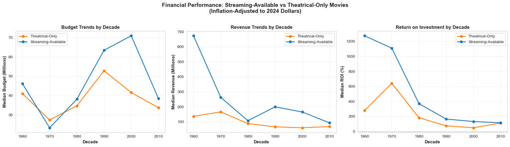

```
======================================================================
FINANCIAL PERFORMANCE COMPARISON
======================================================================

Streaming-Available Movies (n=1,090):
  Median Budget:  $54.3M
  Median Revenue: $139.7M
  Median ROI:     145.9%

Theater-Only Movies (n=2,764):
  Median Budget:  $39.4M
  Median Revenue: $72.3M
  Median ROI:     94.9%
```

```python
# Create decade column for grouping
merged_xmdb_df['decade'] = (merged_xmdb_df['release_year'] // 10) * 10

# Filter to movies with complete financial data
financial_df = merged_xmdb_df[
    merged_xmdb_df['budget_adj_2024'].notna() &
    merged_xmdb_df['revenue_adj_2024'].notna()
].copy()

# Group by decade and streaming availability
decade_comparison = financial_df.groupby(['decade', 'on_streaming']).agg({
    'budget_adj_2024': 'median',
    'revenue_adj_2024': 'median',
    'roi': 'median'
}).reset_index()

# Create figure with 3 subplots
fig, axes = plt.subplots(1, 3, figsize=(18, 5))
fig.suptitle('Financial Performance: Streaming-Available vs Theatrical-Only Movies\n(Inflation-Adjusted to 2024 Dollars)',
             fontsize=14, fontweight='bold', y=1.02)

# Plot 1: Budget over time
for streaming in [False, True]:
    data = decade_comparison[decade_comparison['on_streaming'] == streaming]
    label = 'Streaming-Available' if streaming else 'Theatrical-Only'
    color = '#1f77b4' if streaming else '#ff7f0e'

    axes[0].plot(data['decade'], data['budget_adj_2024'] / 1e6, marker='o', linewidth=2, label=label, color=color)

axes[0].set_xlabel('Decade', fontsize=11, fontweight='bold')
axes[0].set_ylabel('Median Budget (Millions)', fontsize=11, fontweight='bold')
axes[0].set_title('Budget Trends by Decade', fontsize=12, fontweight='bold')
axes[0].legend()
axes[0].grid(True, alpha=0.3)
axes[0].set_xticks(decade_comparison['decade'].unique())

# Plot 2: Revenue over time
for streaming in [False, True]:
    data = decade_comparison[decade_comparison['on_streaming'] == streaming]
    label = 'Streaming-Available' if streaming else 'Theatrical-Only'
    color = '#1f77b4' if streaming else '#ff7f0e'

    axes[1].plot(data['decade'], data['revenue_adj_2024'] / 1e6, marker='o', linewidth=2, label=label, color=color)

axes[1].set_xlabel('Decade', fontsize=11, fontweight='bold')
axes[1].set_ylabel('Median Revenue (Millions)', fontsize=11, fontweight='bold')
axes[1].set_title('Revenue Trends by Decade', fontsize=12, fontweight='bold')
axes[1].legend()
axes[1].grid(True, alpha=0.3)
axes[1].set_xticks(decade_comparison['decade'].unique())

# Plot 3: ROI over time
for streaming in [False, True]:
    data = decade_comparison[decade_comparison['on_streaming'] == streaming]
    label = 'Streaming-Available' if streaming else 'Theatrical-Only'
    color = '#1f77b4' if streaming else '#ff7f0e'

    axes[2].plot(data['decade'], data['roi'], marker='o', linewidth=2, label=label, color=color)

axes[2].set_xlabel('Decade', fontsize=11, fontweight='bold')
axes[2].set_ylabel('Median ROI (%)', fontsize=11, fontweight='bold')
axes[2].set_title('Return on Investment by Decade', fontsize=12, fontweight='bold')
axes[2].legend()
axes[2].grid(True, alpha=0.3)
axes[2].set_xticks(decade_comparison['decade'].unique())
axes[2].axhline(y=0, color='red', linestyle='--', alpha=0.5, linewidth=1)

plt.tight_layout()
plt.show()

# Print summary statistics
print("\n" + "="*70)
print("FINANCIAL PERFORMANCE COMPARISON")
print("="*70)
print(f"\nStreaming-Available Movies (n={financial_df['on_streaming'].sum():,}):")
print(f"  Median Budget:  ${financial_df[financial_df['on_streaming']]['budget_adj_2024'].median()/1e6:.1f}M")
print(f"  Median Revenue: ${financial_df[financial_df['on_streaming']]['revenue_adj_2024'].median()/1e6:.1f}M")
print(f"  Median ROI:     {financial_df[financial_df['on_streaming']]['roi'].median():.1f}%")

print(f"\nTheater-Only Movies (n={(~financial_df['on_streaming']).sum():,}):")
print(f"  Median Budget:  ${financial_df[~financial_df['on_streaming']]['budget_adj_2024'].median()/1e6:.1f}M")
print(f"  Median Revenue: ${financial_df[~financial_df['on_streaming']]['revenue_adj_2024'].median()/1e6:.1f}M")
print(f"  Median ROI:     {financial_df[~financial_df['on_streaming']]['roi'].median():.1f}%")
```

**Visualization 2: Rating Comparison**

**Purpose**: Determines if streaming-available movies have different audience reception

[figure not shown]

```
======================================================================
AUDIENCE RECEPTION COMPARISON
======================================================================

Streaming-Available Movies (n=1,806):
  Mean Rating:   6.25
  Median Rating: 6.30
  Std Dev:       0.90

Theater-Only Movies (n=7,653):
  Mean Rating:   6.09
  Median Rating: 6.15
  Std Dev:       0.93

T-test: t=6.459, p=0.0000
- Statistically significant difference in ratings
```

```python
fig, axes = plt.subplots(2, 2, figsize=(14, 10))
fig.suptitle('Audience Reception: Streaming-Available vs Theatrical-Only Movies', fontsize=14, fontweight='bold', y=0.995)

# Prepare data
ratings_df = merged_xmdb_df[merged_xmdb_df['rating_combined'].notna()].copy()

# Plot 1: Combined Rating Distribution
streaming_ratings = ratings_df[ratings_df['on_streaming']]['rating_combined']
theater_ratings = ratings_df[~ratings_df['on_streaming']]['rating_combined']

axes[0, 0].hist([theater_ratings, streaming_ratings], bins=30, alpha=0.7,
                label=['Theatrical-Only', 'Streaming-Available'],
                color=['#ff7f0e', '#1f77b4'], edgecolor='black')

axes[0, 0].set_xlabel('Combined Rating (TMDb + IMDb Average)', fontsize=10, fontweight='bold')
axes[0, 0].set_ylabel('Number of Movies', fontsize=10, fontweight='bold')
axes[0, 0].set_title('Rating Distribution', fontsize=11, fontweight='bold')
axes[0, 0].legend()
axes[0, 0].grid(True, alpha=0.3, axis='y')

# Plot 2: Box plots
data_to_plot = [theater_ratings, streaming_ratings]
bp = axes[0, 1].boxplot(data_to_plot, tick_labels=['Theatrical-Only', 'Streaming-Available'], patch_artist=True, widths=0.6)

for patch, color in zip(bp['boxes'], ['#ff7f0e', '#1f77b4']):
    patch.set_facecolor(color)
    patch.set_alpha(0.7)

axes[0, 1].set_ylabel('Combined Rating', fontsize=10, fontweight='bold')
axes[0, 1].set_title('Rating Comparison (Box Plot)', fontsize=11, fontweight='bold')
axes[0, 1].grid(True, alpha=0.3, axis='y')

# Plot 3: TMDb vs IMDb scatter
streaming_complete = ratings_df[ratings_df['on_streaming'] & ratings_df['imdb_rating'].notna()]
theater_complete = ratings_df[~ratings_df['on_streaming'] & ratings_df['imdb_rating'].notna()]

axes[1, 0].scatter(theater_complete['tmdb_rating'], theater_complete['imdb_rating'],
                   alpha=0.3, s=10, color='#ff7f0e', label='Theatrical-Only')

axes[1, 0].scatter(streaming_complete['tmdb_rating'], streaming_complete['imdb_rating'],
                   alpha=0.3, s=10, color='#1f77b4', label='Streaming-Available')

axes[1, 0].plot([0, 10], [0, 10], 'r--', alpha=0.5, linewidth=1)
axes[1, 0].set_xlabel('TMDb Rating', fontsize=10, fontweight='bold')
axes[1, 0].set_ylabel('IMDb Rating', fontsize=10, fontweight='bold')
axes[1, 0].set_title('TMDb vs IMDb Rating Agreement', fontsize=11, fontweight='bold')
axes[1, 0].legend()
axes[1, 0].grid(True, alpha=0.3)
axes[1, 0].set_xlim(0, 10)
axes[1, 0].set_ylim(0, 10)

# Plot 4: Rating by decade
decade_ratings = ratings_df.groupby(['decade', 'on_streaming'])['rating_combined'].mean().reset_index()

for streaming in [False, True]:
    data = decade_ratings[decade_ratings['on_streaming'] == streaming]
    label = 'Streaming-Available' if streaming else 'Theatrical-Only'
    color = '#1f77b4' if streaming else '#ff7f0e'

    axes[1, 1].plot(data['decade'], data['rating_combined'], marker='o', linewidth=2, label=label, color=color)

axes[1, 1].set_xlabel('Decade', fontsize=10, fontweight='bold')
axes[1, 1].set_ylabel('Average Rating', fontsize=10, fontweight='bold')
axes[1, 1].set_title('Rating Trends Over Time', fontsize=11, fontweight='bold')
axes[1, 1].legend()
axes[1, 1].grid(True, alpha=0.3)
axes[1, 1].set_xticks(decade_ratings['decade'].unique())

plt.tight_layout()
plt.show()

# Statistics
print("\n" + "="*70)
print("AUDIENCE RECEPTION COMPARISON")
print("="*70)

print(f"\nStreaming-Available Movies (n={len(streaming_ratings):,}):")
print(f"  Mean Rating:   {streaming_ratings.mean():.2f}")
print(f"  Median Rating: {streaming_ratings.median():.2f}")
print(f"  Std Dev:       {streaming_ratings.std():.2f}")

print(f"\nTheater-Only Movies (n={len(theater_ratings):,}):")
print(f"  Mean Rating:   {theater_ratings.mean():.2f}")
print(f"  Median Rating: {theater_ratings.median():.2f}")
print(f"  Std Dev:       {theater_ratings.std():.2f}")

# Statistical test
t_stat, p_value = stats.ttest_ind(streaming_ratings, theater_ratings)

print(f"\nT-test: t={t_stat:.3f}, p={p_value:.4f}")

if p_value < 0.05:
    print("- Statistically significant difference in ratings")

else:
    print("- No statistically significant difference in ratings")
```

**Visualization 3: Genre Distribution**

**Purpose**: Reveals if streaming platforms favor certain genres

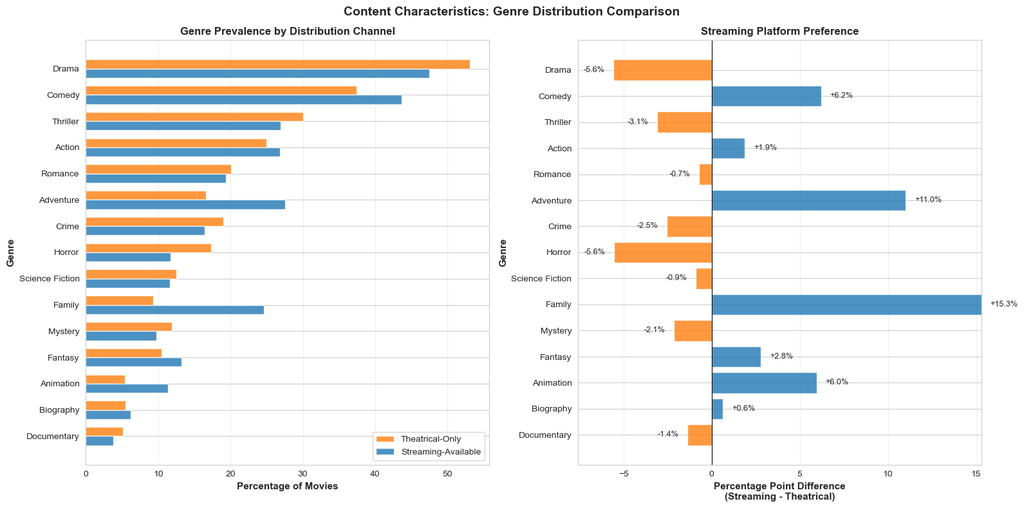

```
======================================================================
TOP 10 GENRES BY DISTRIBUTION CHANNEL
======================================================================

Streaming-Available Movies:
   1. Drama                980 ( 47.5%)
   2. Comedy               900 ( 43.6%)
   3. Adventure            569 ( 27.6%)
   4. Thriller             556 ( 27.0%)
   5. Action               554 ( 26.9%)
   6. Family               507 ( 24.6%)
   7. Romance              400 ( 19.4%)
   8. Crime                339 ( 16.4%)
   9. Fantasy              273 ( 13.2%)
  10. Horror               242 ( 11.7%)

Theater-Only Movies:
   1. Drama                4,656 ( 53.1%)
   2. Comedy               3,283 ( 37.4%)
   3. Thriller             2,635 ( 30.0%)
   4. Action               2,191 ( 25.0%)
   5. Romance              1,763 ( 20.1%)
   6. Crime                1,665 ( 19.0%)
   7. Horror               1,516 ( 17.3%)
   8. Adventure            1,454 ( 16.6%)
   9. Science Fiction      1,095 ( 12.5%)
  10. Mystery              1,046 ( 11.9%)
```

```python
# Extract genres
def extract_genres(genre_tuple):
    """Extract genres from tuple"""
    if isinstance(genre_tuple, tuple):
        return list(genre_tuple)

    return []

# Get all genres for streaming vs non-streaming
streaming_genres = []
theater_genres = []

for _, row in merged_xmdb_df.iterrows():
    genres = extract_genres(row['genres'])

    if row['on_streaming']:
        streaming_genres.extend(genres)

    else:
        theater_genres.extend(genres)

# Count genres
streaming_counts = Counter(streaming_genres)
theater_counts = Counter(theater_genres)

# Get top 15 genres overall
all_genres = list(set(streaming_genres + theater_genres))
genre_totals = {genre: streaming_counts.get(genre, 0) + theater_counts.get(genre, 0) for genre in all_genres}
top_genres = sorted(genre_totals.items(), key=lambda x: x[1], reverse=True)[:15]
top_genre_names = [g[0] for g in top_genres]

# Calculate percentages
streaming_total = len(merged_xmdb_df[merged_xmdb_df['on_streaming']])
theater_total = len(merged_xmdb_df[~merged_xmdb_df['on_streaming']])

streaming_pct = [streaming_counts.get(g, 0) / streaming_total * 100 for g in top_genre_names]
theater_pct = [theater_counts.get(g, 0) / theater_total * 100 for g in top_genre_names]

# Create figure
fig, axes = plt.subplots(1, 2, figsize=(16, 8))
fig.suptitle('Content Characteristics: Genre Distribution Comparison', fontsize=14, fontweight='bold', y=0.98)

# Plot 1: Side-by-side bars
x = np.arange(len(top_genre_names))
width = 0.35

bars1 = axes[0].barh(x - width/2, theater_pct, width, label='Theatrical-Only', color='#ff7f0e', alpha=0.8)
bars2 = axes[0].barh(x + width/2, streaming_pct, width, label='Streaming-Available', color='#1f77b4', alpha=0.8)

axes[0].set_xlabel('Percentage of Movies', fontsize=11, fontweight='bold')
axes[0].set_ylabel('Genre', fontsize=11, fontweight='bold')
axes[0].set_title('Genre Prevalence by Distribution Channel', fontsize=12, fontweight='bold')
axes[0].set_yticks(x)
axes[0].set_yticklabels(top_genre_names)
axes[0].legend()
axes[0].grid(True, alpha=0.3, axis='x')
axes[0].invert_yaxis()

# Plot 2: Difference (Streaming - Theater)
difference = [s - t for s, t in zip(streaming_pct, theater_pct)]
colors = ['#1f77b4' if d > 0 else '#ff7f0e' for d in difference]

bars = axes[1].barh(range(len(top_genre_names)), difference, color=colors, alpha=0.8)
axes[1].set_xlabel('Percentage Point Difference\n(Streaming - Theatrical)', fontsize=11, fontweight='bold')
axes[1].set_ylabel('Genre', fontsize=11, fontweight='bold')
axes[1].set_title('Streaming Platform Preference', fontsize=12, fontweight='bold')
axes[1].set_yticks(range(len(top_genre_names)))
axes[1].set_yticklabels(top_genre_names)
axes[1].axvline(x=0, color='black', linestyle='-', linewidth=0.8)
axes[1].set_xlim(left=min(difference)-2, right=max(difference))
axes[1].grid(True, alpha=0.3, axis='x')
axes[1].invert_yaxis()

# Add percentage labels
for i, (bar, val) in enumerate(zip(bars, difference)):
    x_pos = val + (0.5 if val > 0 else -0.5)
    axes[1].text(x_pos, i, f'{val:+.1f}%', va='center', ha='left' if val > 0 else 'right', fontsize=9)

plt.tight_layout()
plt.show()

# Print top genres
print("\n" + "="*70)
print("TOP 10 GENRES BY DISTRIBUTION CHANNEL")
print("="*70)

print("\nStreaming-Available Movies:")
streaming_top = sorted(streaming_counts.items(), key=lambda x: x[1], reverse=True)[:10]
for i, (genre, count) in enumerate(streaming_top, 1):
    pct = count / streaming_total * 100
    print(f"  {i:2d}. {genre:20s} {count:,d} ({pct:5.1f}%)")

print("\nTheater-Only Movies:")
theater_top = sorted(theater_counts.items(), key=lambda x: x[1], reverse=True)[:10]
for i, (genre, count) in enumerate(theater_top, 1):
    pct = count / theater_total * 100
    print(f"  {i:2d}. {genre:20s} {count:,d} ({pct:5.1f}%)")
```

**Visualization 4: Platform Strategy Matrix**

**Purpose**: Shows how different platforms curate content

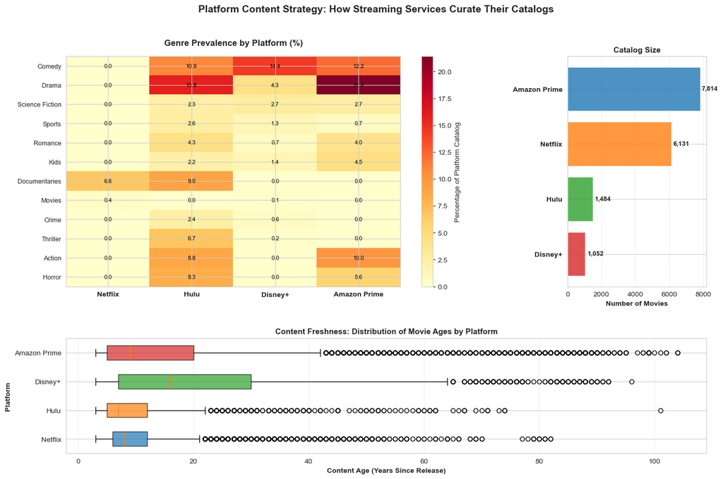

```
======================================================================
PLATFORM STRATEGY ANALYSIS
======================================================================

Netflix:
  Catalog Size:    6,131 movies
  Median Age:      8 years
  Avg Duration:    100 minutes
  Top Genres:      International Movies (2752), Dramas (2427), Comedies (1674)

Hulu:
  Catalog Size:    1,484 movies
  Median Age:      7 years
  Avg Duration:    67 minutes
  Top Genres:      Drama (489), Comedy (337), Documentaries (278)

Disney+:
  Catalog Size:    1,052 movies
  Median Age:      16 years
  Avg Duration:    72 minutes
  Top Genres:      Family (533), Comedy (407), Animation (381)

Amazon Prime:
  Catalog Size:    7,814 movies
  Median Age:      9 years
  Avg Duration:    91 minutes
  Top Genres:      Drama (3206), Comedy (1821), Action (1502)
```

```python
# Analyze streaming catalog by platform
platform_genres = {}
for platform in streaming_catalog_df['platform'].unique():
    platform_movies = streaming_catalog_df[streaming_catalog_df['platform'] == platform]

    # Parse genres from listed_in column
    all_genres_platform = []
    for genres_str in platform_movies['listed_in'].dropna():
        genres = [g.strip() for g in str(genres_str).split(',')]
        all_genres_platform.extend(genres)

    platform_genres[platform] = Counter(all_genres_platform)

# Get top 12 genres overall
all_genres_streaming = []
for genres_list in platform_genres.values():
    all_genres_streaming.extend(genres_list.keys())

genre_totals_streaming = Counter(all_genres_streaming)
top_streaming_genres = [g for g, _ in genre_totals_streaming.most_common(12)]

# Create matrix
platform_names = list(platform_genres.keys())
matrix = np.zeros((len(top_streaming_genres), len(platform_names)))

for i, genre in enumerate(top_streaming_genres):
    for j, platform in enumerate(platform_names):
        total = sum(platform_genres[platform].values())
        matrix[i, j] = platform_genres[platform].get(genre, 0) / total * 100 if total > 0 else 0

# Create figure with heatmap and bar charts
fig = plt.figure(figsize=(16, 10))
gs = fig.add_gridspec(2, 2, height_ratios=[2, 1], width_ratios=[3, 1], hspace=0.3, wspace=0.3)

ax_heat = fig.add_subplot(gs[0, 0])
ax_bar1 = fig.add_subplot(gs[0, 1])
ax_bar2 = fig.add_subplot(gs[1, :])

fig.suptitle('Platform Content Strategy: How Streaming Services Curate Their Catalogs', fontsize=14, fontweight='bold', y=0.98)

# Heatmap
im = ax_heat.imshow(matrix, cmap='YlOrRd', aspect='auto')
ax_heat.set_xticks(range(len(platform_names)))
ax_heat.set_yticks(range(len(top_streaming_genres)))
ax_heat.set_xticklabels(platform_names, fontsize=10, fontweight='bold')
ax_heat.set_yticklabels(top_streaming_genres, fontsize=9)
ax_heat.set_title('Genre Prevalence by Platform (%)', fontsize=12, fontweight='bold', pad=15)

# Add percentage labels
for i in range(len(top_streaming_genres)):
    for j in range(len(platform_names)):
        text = ax_heat.text(j, i, f'{matrix[i, j]:.1f}', ha="center", va="center", color="black", fontsize=8)

plt.colorbar(im, ax=ax_heat, label='Percentage of Platform Catalog')

# Catalog size comparison
platform_sizes = streaming_catalog_df['platform'].value_counts()
colors_platforms = ['#1f77b4', '#ff7f0e', '#2ca02c', '#d62728']
bars = ax_bar1.barh(range(len(platform_sizes)), platform_sizes.values, color=colors_platforms, alpha=0.8)
ax_bar1.set_yticks(range(len(platform_sizes)))
ax_bar1.set_yticklabels(platform_sizes.index, fontsize=10, fontweight='bold')
ax_bar1.set_xlabel('Number of Movies', fontsize=10, fontweight='bold')
ax_bar1.set_title('Catalog Size', fontsize=11, fontweight='bold')
ax_bar1.grid(True, alpha=0.3, axis='x')
ax_bar1.invert_yaxis()

# Add labels
for i, (bar, val) in enumerate(zip(bars, platform_sizes.values)):
    ax_bar1.text(val + 100, i, f'{val:,}', va='center', fontsize=9, fontweight='bold')

# Content age distribution
streaming_catalog_df['age'] = 2024 - streaming_catalog_df['release_year']
platform_ages = []

for platform in platform_names:
    ages = streaming_catalog_df[streaming_catalog_df['platform'] == platform]['age']
    platform_ages.append(ages)

bp = ax_bar2.boxplot(platform_ages, tick_labels=platform_names, patch_artist=True, widths=0.5, vert=False)

for patch, color in zip(bp['boxes'], colors_platforms):
    patch.set_facecolor(color)
    patch.set_alpha(0.7)

ax_bar2.set_xlabel('Content Age (Years Since Release)', fontsize=10, fontweight='bold')
ax_bar2.set_ylabel('Platform', fontsize=10, fontweight='bold')
ax_bar2.set_title('Content Freshness: Distribution of Movie Ages by Platform', fontsize=11, fontweight='bold')
ax_bar2.grid(True, alpha=0.3, axis='x')

plt.show()

# Print platform statistics
print("\n" + "="*70)
print("PLATFORM STRATEGY ANALYSIS")
print("="*70)

for platform in platform_names:
    platform_df = streaming_catalog_df[streaming_catalog_df['platform'] == platform]

    print(f"\n{platform}:")
    print(f"  Catalog Size:    {len(platform_df):5,} movies")
    print(f"  Median Age:      {platform_df['age'].median():.0f} years")
    print(f"  Avg Duration:    {platform_df['duration'].mean():.0f} minutes")

    # Top 3 genres
    platform_genre_counts = platform_genres[platform]
    top_3 = platform_genre_counts.most_common(3)
    print(f"  Top Genres:      ", end="")
    print(", ".join([f"{g} ({c})" for g, c in top_3]))
```

### 5.2: Reflection

If I had more time to complete this project, I would investigate the temporal licensing patterns by incorporating the date_added field from streaming datasets to analyze the lag between theatrical release (release_year) and streaming availability, potentially revealing optimal licensing windows and whether older content (1960s-1980s) faces systematic barriers to streaming acquisition compared to recent releases (2000s-2010s).

Additionally, integrating director and cast data would enable analysis of whether certain talent consistently drives streaming licensing decisions—for example, whether films featuring specific A-list actors show higher streaming acquisition rates regardless of box office performance, suggesting star power influences platform curation beyond pure financial metrics.

Finally, I would extend the analysis beyond 2015 to capture the streaming boom years (2016-2024), examining whether theatrical studios began modifying release strategies specifically for streaming licensing (shorter theatrical windows, "streaming-first" theatrical releases) and whether platforms shifted from licensing theatrical catalogs toward producing streaming-original content, fundamentally changing the theatrical-streaming relationship dynamics.